# IBM Capstone - Weather AI

Alexander Portelli

2024-11-03

# **IBM Data Analysis with Excel & R**

Once again I’m involved with bike sharing data. This time, I’ve been hired by a Weather AI: data-analytics company. My task is to analyse how weather affect’s bike sharing demand in Seoul.  
During this project I’ll be using packages Tidyverse, tidymodels, jsonlite, glmnet, patchwork, caret, yardstick, lubridate, DBI, RSQLite, httr, rvest, kableExtra, viridis, ggridges, to perform the following:  
-Collecting data from multiple sources  
-Perform data wrangling & preparation  
-Perform data analysis with SQL & visualisation  
-Modelling the data with linear regressions  
-Using the results predict bike counts from the forecast data  
The 3 data sets I’m going to be collecting are:  
A list of bike share companies from Wikipedia that lists location and is going to be used to make a map with points for all the bike share companies around the globe.  
Then forecast data from OpenWeatherAPI for the upcoming 5 days  
A supplied data set of Korean bike sharing data that was made in 2018.  
Now this isn’t so much a means to build a 100pct usable regression model as I’m comparing 2018 data with 2024.  
I completely understand that this isn’t a realistic or practical model but this is the actual capstone project set out by IBM.  
With the amazing content I learnt during this IBM course + their business intelligence course I’m going to fuse what I’ve learnt and apply it to this project to show off what a great course it was & struggle a bit with it. I’ve put a lot of thought behind what I want to do while ensuring to tick off the 5 points above in this project.  
This documentation is quite long, I have included a summary on my [github](https://github.com/PortelliA/IBM-Capstone) in the readME section.  
This analysis represents my journey in learning and applying various methods and models in regression analysis. It’s by no means a way to educate others but to document my own understanding and approach, the method to the madness so to say.  
While I could present the results as if I were an expert, the truth is, this grasshopper is far from it. Not even a month into exploring linear regression.  
The purpose of this write-up is to convey my process and thoughts aloud as I interpret each step and result, making the learning experience personal and authentic.  
As tradition I want to mention a couple of people who on YouTube have helped explain a couple of things whenever I was unsure of something I was learning  
[Equitable Equations](https://www.youtube.com/@EquitableEquations): Once again this gentleman has assisted me through his video’s really breaking down what simple linear regression is, while the explanation from IBM was great, it was quite detailed & hard to absorb at first. EE’s video on the matter really helped breakdown the topic covered in the course and allowed me to interpret what I was learning more effectively.  
[Andrew Coach](https://www.youtube.com/@AndrewCouch): Refining my Rmarkdown skills thanks to his video’s, while the video’s he made weren’t necessarily about Rmarkdown. He would majority of the time be running his script on the platform so watching how he goes about it gave me idea’s. His video’s on visualisations really helped & I hope it is apparent with the visuals in this documentation.  
[Alex The Analyst](https://www.youtube.com/@AlexTheAnalyst): I was watching his SQL tutorial alongside both the courses models on SQL. His video’s are contructed very well where the context of his examples are relatable to not only the data he is working with but what the insights one can bring out. Giving situations were in his own personal experience he has used certain functions.  
[Quant Psych](https://www.youtube.com/@QuantPsych): In this course I learnt about polynomial regression, as it is something abit hard to interpret for the first time I went to look into it on YouTube, this gentleman’s channel covered the topic well, he has a lot of other video’s that I’ve looked into, they all are fun, informative & relatively easy to interpret.

## **Web scraping bikesharing information**

The table I’m grabbing is from wikipedia

```r
#The URL Im using
url <- "https://en.wikipedia.org/wiki/List_of_bicycle-sharing_systems"
#Read's the URL
doc <- read_html(url)
#Grabs the tables
tables <- html_nodes(doc, "table")
#Lists the tables
num_tables <- length(tables)
```

With the code chunk above, I was able to locate 4 tables in the URL Which I’ll now grab those 4 tables to have a look as to which I need, out of habit I’m going to do fill = TRUE to ensure I capture it all, I’ll be cleaning later so no issue.

```r
table1 <- html_table(doc, fill = TRUE)[[1]]
table2 <- html_table(doc, fill = TRUE)[[2]]
table3 <- html_table(doc, fill = TRUE)[[3]]
table4 <- html_table(doc, fill = TRUE)[[4]]
```

Table 1 is the table I’m after, table 2,3,4 if you were to scroll down to the bottom of the page is a multi leveled table.  
Each table is broken down as:  
table2: *15 obs, 8 variables*  
table3: *4 obs, 2 variables*  
table4: *3 obs, 2 variables*.  
I wont be using these tables.  
table1 has *840 obs, 8 variables*.  
From here I would save the doc to complete the first section of this project.

## **OpenWeather API’s Call**

Next using OpenWeather API I’m going to get the forecast data for the upcoming 5 days for a list of cities.  
Using my own API key I was able to retrieve weather data. I’ve include the picture below for seoul to show what it looked like. Going forward I’m going to retrieve **Seoul** and 6 others being **Brisbane**(interesting weather and in AUS), **Chicago**(need to check in on the weather from my previous project, **Tokyo**, **Copenhagen**, **Berlin** & **London**.  
Next using OpenWeather API I’m going to get the forecast data for the upcoming 5 days for a list of cities.  
The call will be slightly different as this result below was a test and you can see data/2.5/weather in the URL which is on a current basis but ill be using data/2.5/forecast which will grab for the 5 upcoming days

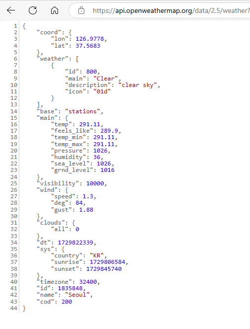

This code chunk below was 5 hours in the making. The previous method I was trying was declaring table present like `city <- c(), weather <-c() etc etc` & then use nrows with the declared `api-id/cities/url` to create a path to the individual list attributes.  
It was confusing as I was able to get info using:  
`content <- content(response, as = "text")` & `parsed_content <- fromJSON(content, flatten = TRUE` as IBM suggested, but when pulling the data the weather variables id/main/description/icon were not being extracted thus halting the whole process.  
So I could see the file but couldn’t convert it. Turning to Google it seems someone ran into this issue & found the solution you see here. The `help()` for `str_glue` describes it as a powerful & elegant syntax for interpolating strings. I believe it.

```r
# these are the cities for which I want to hone in on
cities <- c("Brisbane", "Chicago", "Tokyo", "Seoul", "London", "Copenhagen", "Berlin")
# create an empty shell table that I'll put all the information into
main_df <- data.frame()
# Function to get weather forecast by city
get_weather_forecast_by_cities <- function(url) {
  web_content <- httr::GET(url)
  web_content <- content(web_content, "text")
  json_data <- fromJSON(web_content, flatten = TRUE)
  df <- as.data.frame(json_data)
  return(df)
}
# Iterate through each city to fetch and bind the data
for (city_name in cities) {
  url <- str_glue("http://api.openweathermap.org/data/2.5/forecast?q={city_name}&appid={api_id}&units=metric")
  main_df <- bind_rows(main_df, get_weather_forecast_by_cities(url))
}
```

Below is a picture of the “main_df” pulled, it highlights the table that was within a column that was causing me “abit” of trouble

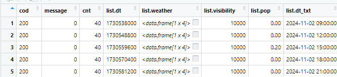

IBM suppied the Seoul bike data in a CSV file so I wont be needing to retrieve anything else.

## **SQL data analysis**

So in a separate page to not congest the review I conducted the actual data cleaning.  
I have included the raw files, cleaned data files & the script to build them on my github.  
I’m going to be using RSQLite to do some data exploration, I’ve hidden the code chunk that creates the SQL table that I’ll include in the R-script as it was quite large, below I’ve displayed the column names I’m working with, the first table is the Seoul bike data, the next is the November forecast 2024 table & last is the wikipedia world bike table.  
I’ll explore the Seoul bike data prominently then the forecast data I’ll get one or two, just because I’ll be focusing my regression on the Seoul data where the final model will be used for the forecast data. When it comes to visualisation I will explore more the forecast data  
**Context on the data**  
Starting with the Seoul bike share data:**year_ride_seoul**. The dataset contains columns for rented bike counts, weather conditions and time of year. The first observation starts on the 01/12/2017 at 00:00 and finishes at 30/11/2018 23:00. Every observation is by the hour so we have a total of 8,760 observations. This data was composed by IBM using a Korean bike sharing database(I’ve left the link in the data cleaning script) & some sort of weather API(was not disclosed).

```
## DATE | RENTED_BIKE_COUNT | HOUR | TEMPERATURE | HUMIDITY | WIND_SPEED | VISIBILITY | DEW_POINT_TEMPERATURE | SOLAR_RADIATION | RAINFALL | SNOWFALL | SEASONS | HOLIDAY | FUNCTIONING_DAY
```

**Forecast_data**  
The second dataset is the WeatherAPI table that I extracted above, It starts on the 02/11/2024 and goes to 07/11/2024, I have cleaned the file and it has recordings of weather for Seoul, Brisbane, Chicago, Tokyo, Copenhagen, Berlin & London. It also records the City name, population. The dataset is in 3 hour interval with a total of 280 observations.

```
## MAIN | DESCRIPTION | VISIBILITY | PROBABILITY_OF_PRECIPITATION | DATE | HOUR_INTERVAL | TEMPERATURE | FEELS_LIKE | TEMP_MIN | TEMP_MAX | PRESSURE | LIST.MAIN.SEA_LEVEL | GRND_LEVEL | HUMIDITY | TEMP_KF | CLOUDS_ALL | WIND_SPEED | WIND_DEG | WIND_GUST | SYS_POD | RAIN_OVER_3H | CITY_NAME | CITY_CO…
```

**wiki_world_bike**  
The last dataset is the wiki table that I pulled, unfortunately Wikipedia has removed a key column which is the actual bicycle amount column, I’ve alternatively used a IBM supplied dataset that I still had to clean & is in the cleaning file aswell. This dataset contains all bike sharing companies(limited to what is actually listed on Wikipedia) around the world & are divided into countries/states.

```
## COUNTRY | CITY | SYSTEM | BICYCLES
```

### Bike count stats by time

```r
time_bike_counts <- dbGetQuery(con, "SELECT
                                     CASE
                                       WHEN CAST(HOUR AS INTEGER) BETWEEN 0 AND 2 THEN '00:00-02:59'
                                       WHEN CAST(HOUR AS INTEGER) BETWEEN 3 AND 5 THEN '03:00-05:59'
                                       WHEN CAST(HOUR AS INTEGER) BETWEEN 6 AND 8 THEN '06:00-08:59'
                                       WHEN CAST(HOUR AS INTEGER) BETWEEN 9 AND 11 THEN '09:00-11:59'
                                       WHEN CAST(HOUR AS INTEGER) BETWEEN 12 AND 14 THEN '12:00-14:59'
                                       WHEN CAST(HOUR AS INTEGER) BETWEEN 15 AND 17 THEN '15:00-17:59'
                                       WHEN CAST(HOUR AS INTEGER) BETWEEN 18 AND 20 THEN '18:00-20:59'
                                       WHEN CAST(HOUR AS INTEGER) BETWEEN 21 AND 23 THEN '21:00-23:59'
                                     END AS hour_block,
                                     ROUND(AVG(RENTED_BIKE_COUNT), 2) AS avg_bike_count,
                                     MEDIAN(RENTED_BIKE_COUNT) AS median_bike_count,
                                     MAX(RENTED_BIKE_COUNT) AS max_bike_count,
                                     MIN(RENTED_BIKE_COUNT) AS min_bike_count
                                     FROM bike_seoul
                                     GROUP BY hour_block
                                     ORDER BY hour_block;")

time_bike_counts %>%
  kable("html") %>%
  kable_styling(bootstrap_options = c("striped", "hover", "condensed"))
```

| hour_block | avg_bike_count | median_bike_count | max_bike_count | min_bike_count |
| --- | --- | --- | --- | --- |
| 00:00-02:59 | 441.57 | 390.0000 | 1394 | 9 |
| 03:00-05:59 | 164.97 | 152.0000 | 644 | 2 |
| 06:00-08:59 | 663.01 | 452.0000 | 2495 | 3 |
| 09:00-11:59 | 616.68 | 655.0000 | 1478 | 2 |
| 12:00-14:59 | 762.70 | 769.0000 | 2128 | 4 |
| 15:00-17:59 | 1008.96 | 1004.0000 | 2664 | 7 |
| 18:00-20:59 | 1307.00 | 1321.7037 | 3556 | 8 |
| 21:00-23:59 | 909.11 | 897.4222 | 2505 | 4 |

### Affect of holidays by season

```r
holiday_season <- dbGetQuery(con, "SELECT SEASONS, HOLIDAY,
                             COUNT(RENTED_BIKE_COUNT) / 24 AS count,
                             ROUND(AVG(RENTED_BIKE_COUNT), 2) AS avg_bike_count,
                             MEDIAN(RENTED_BIKE_COUNT) AS median_bike_count,
                             MAX(RENTED_BIKE_COUNT) AS max_bike_count,
                             MIN(RENTED_BIKE_COUNT) AS min_bike_count
                             FROM bike_seoul
                             GROUP BY SEASONS, HOLIDAY
                             ORDER BY SEASONS, HOLIDAY;")
holiday_season %>%
  kable("html") %>%
  kable_styling(bootstrap_options = c("striped", "hover", "condensed"))
```

| SEASONS | HOLIDAY | count | avg_bike_count | median_bike_count | max_bike_count | min_bike_count |
| --- | --- | --- | --- | --- | --- | --- |
| Autumn | Holiday | 5 | 942.91 | 900.000 | 2400 | 105 |
| Autumn | No Holiday | 86 | 920.91 | 849.216 | 3298 | 2 |
| Spring | Holiday | 3 | 635.31 | 366.500 | 2082 | 11 |
| Spring | No Holiday | 89 | 749.99 | 610.500 | 3251 | 2 |
| Summer | Holiday | 2 | 1022.15 | 925.000 | 2163 | 218 |
| Summer | No Holiday | 90 | 1034.34 | 904.500 | 3556 | 9 |
| Winter | Holiday | 8 | 156.63 | 138.000 | 671 | 3 |
| Winter | No Holiday | 82 | 232.26 | 212.000 | 937 | 7 |

### Bike count stats by season

```r
season_bike_counts <- dbGetQuery(con, "SELECT SEASONS,
                                     ROUND(AVG(RENTED_BIKE_COUNT), 2) AS avg_bike_count,
                                     MAX(RENTED_BIKE_COUNT) AS max_bike_count,
                                     MIN(RENTED_BIKE_COUNT) AS min_bike_count,
                                     MEDIAN(RENTED_BIKE_COUNT) AS median_bike_count
                                     FROM bike_seoul
                                     GROUP BY SEASONS
                                     ORDER BY SEASONS;")
season_bike_counts%>%
  kable("html") %>%
  kable_styling(bootstrap_options = c("striped", "hover", "condensed"))
```

| SEASONS | avg_bike_count | max_bike_count | min_bike_count | median_bike_count |
| --- | --- | --- | --- | --- |
| Autumn | 922.11 | 3298 | 2 | 852.5 |
| Spring | 746.25 | 3251 | 2 | 605.0 |
| Summer | 1034.07 | 3556 | 9 | 905.5 |
| Winter | 225.54 | 937 | 3 | 203.0 |

### Grouping Temp w/ Bike counts

```r
temperature_grouping <- dbGetQuery(con, "SELECT
                                   CASE
                                   WHEN TEMPERATURE < -10 THEN '<-10'
                                   WHEN TEMPERATURE < 0 THEN '-10 to 0'
                                   WHEN TEMPERATURE < 5 THEN '0 to 5'
                                   WHEN TEMPERATURE < 15 THEN '5 to 15'
                                   WHEN TEMPERATURE < 30 THEN '15-30'
                                   ELSE '> 30'
                                   END AS temp_range,
                                   ROUND(AVG(RENTED_BIKE_COUNT), 2) AS avg_bike_count,
                                   MAX(RENTED_BIKE_COUNT) AS max_bike_count,
                                   MIN(RENTED_BIKE_COUNT) AS min_bike_count,
                                   SUM(RENTED_BIKE_COUNT) AS sum_bike_count,
                                   COUNT(RENTED_BIKE_COUNT) AS count_in_temp_bracket
                                   FROM bike_seoul
                                   GROUP BY temp_range
                                   ORDER BY TEMPERATURE;")
temperature_grouping%>%
  kable("html") %>%
  kable_styling(bootstrap_options = c("striped", "hover", "condensed"))
```

| temp_range | avg_bike_count | max_bike_count | min_bike_count | sum_bike_count | count_in_temp_bracket |
| --- | --- | --- | --- | --- | --- |
| <-10 | 141.81 | 621 | 20 | 32050 | 226 |
| -10 to 0 | 208.51 | 1671 | 9 | 251671 | 1207 |
| 0 to 5 | 327.35 | 1910 | 3 | 346988 | 1060 |
| 5 to 15 | 637.24 | 2618 | 2 | 1356039 | 2128 |
| 15-30 | 1067.61 | 3556 | 2 | 3856223 | 3612 |
| > 30 | 1117.76 | 3238 | 215 | 589058 | 527 |

### Temp stats by Season

```r
temp_stats <- dbGetQuery(con, "SELECT SEASONS,
       ROUND(AVG(TEMPERATURE), 2) AS avg_temp,
       MAX(TEMPERATURE) as max_temp,
       MIN(TEMPERATURE) as min_temp
FROM bike_seoul
GROUP BY SEASONS;")
temp_stats %>%
  kable("html") %>%
  kable_styling(bootstrap_options = c("striped", "hover", "condensed"))
```

| SEASONS | avg_temp | max_temp | min_temp |
| --- | --- | --- | --- |
| Autumn | 14.12 | 30.5 | -3.0 |
| Spring | 13.05 | 29.4 | -6.6 |
| Summer | 26.59 | 39.4 | 16.3 |
| Winter | -2.54 | 10.3 | -17.8 |

### MAX in weather variables

```r
max_weather <- dbGetQuery(con, "SELECT SEASONS,
    MAX(WIND_SPEED) AS max_wind,
    MAX(HUMIDITY) AS max_humidity,
    MAX(DEW_POINT_TEMPERATURE) AS max_dew_temp,
    MAX(SOLAR_RADIATION) AS max_solar,
    MAX(RAINFALL) AS max_rainfall,
    MAX(VISIBILITY) AS max_visibility
FROM bike_seoul
GROUP BY SEASONS;")
max_weather %>%
  kable("html") %>%
  kable_styling(bootstrap_options = c("striped", "hover", "condensed"))
```

| SEASONS | max_wind | max_humidity | max_dew_temp | max_solar | max_rainfall | max_visibility |
| --- | --- | --- | --- | --- | --- | --- |
| Autumn | 5.7 | 97 | 23.9 | 3.12 | 18.0 | 2000 |
| Spring | 7.4 | 98 | 22.0 | 3.52 | 35.0 | 2000 |
| Summer | 6.9 | 98 | 27.2 | 3.45 | 29.5 | 2000 |
| Winter | 6.7 | 97 | 4.2 | 2.52 | 9.5 | 2000 |

### MIN in weather variables

```r
min_weather <- dbGetQuery(con, "SELECT SEASONS,
    MIN(WIND_SPEED) AS min_wind,
    MIN(HUMIDITY) AS min_humidity,
    MIN(DEW_POINT_TEMPERATURE) AS min_dew_temp,
    MIN(SOLAR_RADIATION) AS min_solar,
    MIN(RAINFALL) AS min_rainfall,
    MIN(VISIBILITY) AS min_visibility
FROM bike_seoul
GROUP BY SEASONS;")
min_weather %>%
  kable("html") %>%
  kable_styling(bootstrap_options = c("striped", "hover", "condensed"))
```

| SEASONS | min_wind | min_humidity | min_dew_temp | min_solar | min_rainfall | min_visibility |
| --- | --- | --- | --- | --- | --- | --- |
| Autumn | 0.0 | 13 | -19.0 | 0 | 0 | 33 |
| Spring | 0.1 | 0 | -18.1 | 0 | 0 | 27 |
| Summer | 0.0 | 21 | 0.0 | 0 | 0 | 70 |
| Winter | 0.0 | 14 | -30.6 | 0 | 0 | 54 |

### AVG in weather for year

```r
weather_averages_year <- dbGetQuery(con, "SELECT
       ROUND(AVG(HUMIDITY), 2) AS avg_humidity,
       ROUND(AVG(WIND_SPEED), 2) as avg_wind_speed,
       ROUND(AVG(DEW_POINT_TEMPERATURE), 2) as avg_dew_temp,
       ROUND(AVG(SOLAR_RADIATION), 2) as avg_solar,
       ROUND(AVG(RAINFALL), 2) as avg_rainfall,
       ROUND(AVG(VISIBILITY), 0) AS avg_visibility
FROM bike_seoul;")
weather_averages_year %>%
  kable("html") %>%
  kable_styling(bootstrap_options = c("striped", "hover", "condensed"))
```

| avg_humidity | avg_wind_speed | avg_dew_temp | avg_solar | avg_rainfall | avg_visibility |
| --- | --- | --- | --- | --- | --- |
| 58.23 | 1.72 | 4.07 | 0.57 | 0.15 | 1437 |

### Weather Averages by Season

```r
weather_averages <- dbGetQuery(con, "SELECT SEASONS,
       ROUND(AVG(HUMIDITY), 2) AS avg_humidity,
       ROUND(AVG(WIND_SPEED), 2) as avg_wind_speed,
       ROUND(AVG(DEW_POINT_TEMPERATURE), 2) as avg_dew_temp,
       ROUND(AVG(SOLAR_RADIATION), 2) as avg_solar,
       ROUND(AVG(RAINFALL), 2) as avg_rainfall,
       ROUND(AVG(VISIBILITY), 0) as avg_visibility
FROM bike_seoul
GROUP BY SEASONS;")
weather_averages %>%
  kable("html") %>%
  kable_styling(bootstrap_options = c("striped", "hover", "condensed"))
```

| SEASONS | avg_humidity | avg_wind_speed | avg_dew_temp | avg_solar | avg_rainfall | avg_visibility |
| --- | --- | --- | --- | --- | --- | --- |
| Autumn | 59.23 | 1.49 | 5.50 | 0.52 | 0.12 | 1561 |
| Spring | 58.78 | 1.87 | 4.12 | 0.69 | 0.18 | 1240 |
| Summer | 64.98 | 1.61 | 18.75 | 0.76 | 0.25 | 1502 |
| Winter | 49.74 | 1.92 | -12.42 | 0.30 | 0.03 | 1446 |

### Rainfall & Snowfall Grouping

```r
weather_grouping <- dbGetQuery(con, "SELECT
                               CASE
                               WHEN RAINFALL = 0 THEN 'No Rain'
                               WHEN RAINFALL < 5 THEN 'Light Rain'
                               WHEN RAINFALL < 15 THEN 'Moderate Rain'
                               ELSE 'Heavy Rain'
                               END AS rainfall_range,
                               CASE
                               WHEN SNOWFALL = 0 THEN 'No Snow'
                               WHEN SNOWFALL < 5 THEN 'Light Snow'
                               ELSE 'Moderate Snow'
                               END AS snowfall_range,
                               ROUND(AVG(VISIBILITY), 2) AS avg_visibility,
                               COUNT(VISIBILITY) AS occurances
                               FROM bike_seoul
                               GROUP BY rainfall_range, snowfall_range
                               ORDER BY RAINFALL, SNOWFALL;")
weather_grouping%>%
  kable("html") %>%
  kable_styling(bootstrap_options = c("striped", "hover", "condensed"))
```

| rainfall_range | snowfall_range | avg_visibility | occurances |
| --- | --- | --- | --- |
| No Rain | No Snow | 1488.17 | 7817 |
| No Rain | Light Snow | 1258.85 | 410 |
| No Rain | Moderate Snow | 975.60 | 5 |
| Light Rain | Light Snow | 539.80 | 25 |
| Light Rain | No Snow | 875.03 | 430 |
| Light Rain | Moderate Snow | 944.50 | 2 |
| Moderate Rain | No Snow | 574.39 | 57 |
| Moderate Rain | Moderate Snow | 34.00 | 1 |
| Heavy Rain | No Snow | 627.00 | 13 |

### Breakdown of day

```r
day_breakdown <- dbGetQuery(con, "SELECT
                                               HOLIDAY,
                                               FUNCTIONING_DAY,
                                               COUNT(*) AS occurrences
                                               FROM bike_seoul
                                               GROUP BY HOLIDAY, FUNCTIONING_DAY
                                               ORDER BY HOLIDAY, FUNCTIONING_DAY;")
day_breakdown%>%
  kable("html") %>%
  kable_styling(bootstrap_options = c("striped", "hover", "condensed"))
```

| HOLIDAY | FUNCTIONING_DAY | occurrences |
| --- | --- | --- |
| Holiday | No | 24 |
| Holiday | Yes | 408 |
| No Holiday | No | 271 |
| No Holiday | Yes | 8057 |

### Forecast average’s for Seoul

```r
Average_stats_daily <- dbGetQuery(con, "SELECT
                            DATE,
                            ROUND(AVG(TEMPERATURE), 2) AS avg_temp,
                            ROUND(AVG(HUMIDITY), 2) AS avg_humidity,
                            ROUND(AVG(RAIN_OVER_3H), 2) AS avg_rainfall,
                            ROUND(AVG(WIND_SPEED), 2) AS avg_wind_speed,
                            ROUND(AVG(VISIBILITY), 2) AS avg_visibility,
                            ROUND(AVG(CLOUDS_ALL), 2) AS avg_cloud_coverage
                            FROM forecast
                            WHERE CITY_NAME = 'Seoul'
                            GROUP BY DATE
                            ORDER BY DATE;")
Average_stats_daily%>%
  kable("html") %>%
  kable_styling(bootstrap_options = c("striped", "hover", "condensed"))
```

| DATE | avg_temp | avg_humidity | avg_rainfall | avg_wind_speed | avg_visibility | avg_cloud_coverage |
| --- | --- | --- | --- | --- | --- | --- |
| 02/11/2024 | 18.22 | 58.20 | 0.00 | 1.44 | 10000 | 0.00 |
| 03/11/2024 | 18.09 | 63.25 | 0.22 | 2.85 | 10000 | 28.38 |
| 04/11/2024 | 12.42 | 44.75 | 0.02 | 4.38 | 10000 | 60.25 |
| 05/11/2024 | 9.82 | 31.13 | 0.00 | 3.82 | 10000 | 14.63 |
| 06/11/2024 | 6.87 | 27.88 | 0.00 | 4.74 | 10000 | 0.13 |
| 07/11/2024 | 8.08 | 20.67 | 0.00 | 1.01 | 10000 | 0.00 |

### “Feels Like Analysis” for Seoul

```r
feels_like_analysis <- dbGetQuery(con, "SELECT DATE,
    CASE
      WHEN FEELS_LIKE < 8 THEN 'Under 8'
      WHEN FEELS_LIKE < 12 THEN 'Under 12'
      ELSE '12 & above'
    END AS Feels_like_range,
    ROUND(AVG(TEMPERATURE), 2) AS avg_temp,
    MAIN,
    DESCRIPTION AS forecast,
    COUNT(DESCRIPTION) AS occurrence
  FROM
    forecast
  WHERE
    CITY_NAME = 'Seoul'
  GROUP BY
    DATE, MAIN, DESCRIPTION, Feels_like_range
  ORDER BY
    DATE, MAIN, DESCRIPTION, Feels_like_range;")
feels_like_analysis%>%
  kable("html") %>%
  kable_styling(bootstrap_options = c("striped", "hover", "condensed"))
```

| DATE | Feels_like_range | avg_temp | MAIN | forecast | occurrence |
| --- | --- | --- | --- | --- | --- |
| 02/11/2024 | 12 & above | 18.22 | Clear | clear sky | 5 |
| 03/11/2024 | 12 & above | 18.75 | Clear | clear sky | 5 |
| 03/11/2024 | 12 & above | 16.98 | Rain | light rain | 3 |
| 04/11/2024 | 12 & above | 16.32 | Clear | clear sky | 1 |
| 04/11/2024 | Under 12 | 11.99 | Clouds | broken clouds | 1 |
| 04/11/2024 | Under 8 | 9.49 | Clouds | broken clouds | 1 |
| 04/11/2024 | Under 12 | 9.16 | Clouds | overcast clouds | 2 |
| 04/11/2024 | 12 & above | 15.02 | Clouds | scattered clouds | 1 |
| 04/11/2024 | Under 12 | 10.84 | Clouds | scattered clouds | 1 |
| 04/11/2024 | 12 & above | 17.34 | Rain | light rain | 1 |
| 05/11/2024 | Under 12 | 10.51 | Clear | clear sky | 1 |
| 05/11/2024 | Under 8 | 8.47 | Clear | clear sky | 4 |
| 05/11/2024 | Under 12 | 9.54 | Clouds | broken clouds | 1 |
| 05/11/2024 | Under 12 | 12.31 | Clouds | few clouds | 2 |
| 06/11/2024 | Under 8 | 6.87 | Clear | clear sky | 8 |
| 07/11/2024 | Under 12 | 8.62 | Clear | clear sky | 1 |
| 07/11/2024 | Under 8 | 7.82 | Clear | clear sky | 2 |

### Seoul Population & Bikes amount

```r
Seoul_information<- dbGetQuery(con, "SELECT DISTINCT B.BICYCLES, B.CITY, B.COUNTRY, F.CITY_COORD_LAT, F.CITY_COORD_LON, F.CITY_POPULATION
FROM bike_world AS B
LEFT JOIN forecast AS F ON B.CITY = F.CITY_NAME
WHERE B.CITY = 'Seoul'")
Seoul_information%>%
  kable("html") %>%
  kable_styling(bootstrap_options = c("striped", "hover", "condensed"))
```

| BICYCLES | CITY | COUNTRY | CITY_COORD_LAT | CITY_COORD_LON | CITY_POPULATION |
| --- | --- | --- | --- | --- | --- |
| 20000 | Seoul | South Korea | 37.5683 | 126.9778 | 10349312 |

### SUMMARY

| DATE | bike_usage_per_day | avg_daily_temp |
| --- | --- | --- |
| 25/09/18 | 23350.00 | 17.49167 |
| 24/09/18 | 17259.00 | 17.82083 |
| 23/09/18 | 20060.00 | 19.41250 |
| 09/10/18 | 22130.74 | 15.00000 |
| 03/10/18 | 30349.00 | 17.24167 |

```
## Clouds | Rain | Clear
```

```
## broken clouds | light rain | scattered clouds | overcast clouds | clear sky | few clouds | moderate rain | heavy intensity rain
```

Average Temperature: 6.87°C to 18.22°C  
Average Humidity: 20.67% to 63.25%  
Average Rainfall: 0.00mm to 0.22mm  
Average Wind Speed: 1.01 km/h to 4.74 km/h  
Average Visibility: Consistently 10000 meters  
Average Cloud Coverage: 0.00% to 60.25%  
**Comparing same variables between Seoul bike-sharing data and forecast data**  
As I want to forecast Bike usage based on the forecast data I wanted to initially compare the average for the same days that fall in November. Because both my date columns start with day/month, all I had to do was declare the matching first 5 text from both columns date column. I wish I knew how to group by date based on the results, I’m sure there is a way but I couldn’t figure it out.

```r
result1 <- dbGetQuery(con, "
  SELECT
    ROUND(AVG(B.TEMPERATURE), 2) AS avg_temp,
    ROUND(AVG(F.TEMPERATURE), 2) AS avg_temp_F,
    ROUND(AVG(B.HUMIDITY), 2) AS avg_humidity,
    ROUND(AVG(F.HUMIDITY), 2) AS avg_humidity_F,
    ROUND(AVG(B.VISIBILITY), 2) AS avg_visibility,
    ROUND(AVG(F.VISIBILITY), 2) AS avg_visibility_F
  FROM bike_seoul AS B
  LEFT JOIN forecast AS F
    ON SUBSTR(B.DATE, 1, 5) = SUBSTR(F.DATE, 1, 5)
  WHERE F.CITY_NAME = 'Seoul' AND B.SEASONS = 'Autumn';
")
result2 <- dbGetQuery(con, "
  SELECT
    AVG(B.RAINFALL) AS avg_rainfall,
    AVG(F.RAIN_OVER_3H) AS avg_rainfall_F,
    ROUND(AVG(B.WIND_SPEED), 2) AS avg_wind_speed,
    ROUND(AVG(F.WIND_SPEED), 2) AS avg_wind_speed_F
  FROM bike_seoul AS B
  LEFT JOIN forecast AS F
    ON SUBSTR(B.DATE, 1, 5) = SUBSTR(F.DATE, 1, 5)
  WHERE F.CITY_NAME = 'Seoul' AND B.SEASONS = 'Autumn';
")
result3 <- dbGetQuery(con, "
  SELECT
    CASE
      WHEN CAST(HOUR AS INTEGER) BETWEEN 0 AND 2 THEN '00:00-02:59'
      WHEN CAST(HOUR AS INTEGER) BETWEEN 3 AND 5 THEN '03:00-05:59'
      WHEN CAST(HOUR AS INTEGER) BETWEEN 6 AND 8 THEN '06:00-08:59'
      WHEN CAST(HOUR AS INTEGER) BETWEEN 9 AND 11 THEN '09:00-11:59'
      WHEN CAST(HOUR AS INTEGER) BETWEEN 12 AND 14 THEN '12:00-14:59'
      WHEN CAST(HOUR AS INTEGER) BETWEEN 15 AND 17 THEN '15:00-17:59'
      WHEN CAST(HOUR AS INTEGER) BETWEEN 18 AND 20 THEN '18:00-20:59'
      WHEN CAST(HOUR AS INTEGER) BETWEEN 21 AND 23 THEN '21:00-23:59'
    END AS hour_block,
    ROUND(AVG(SOLAR_RADIATION), 2) AS avg_solar_radiation,
    MEDIAN(SOLAR_RADIATION) AS median_solar_radiation
  FROM bike_seoul
  WHERE SEASONS = 'Autumn'
  GROUP BY hour_block
  ORDER BY hour_block;
")

result1%>% kable("html") %>% kable_styling()
```

| avg_temp | avg_temp_F | avg_humidity | avg_humidity_F | avg_visibility | avg_visibility_F |
| --- | --- | --- | --- | --- | --- |
| 11.66 | 12.32 | 62.35 | 42.23 | 919.45 | 10000 |

```r
result2%>% kable("html") %>% kable_styling()
```

| avg_rainfall | avg_rainfall_F | avg_wind_speed | avg_wind_speed_F |
| --- | --- | --- | --- |
| 0.00625 | 0.048 | 1.14 | 3.41 |

```r
result3 %>% kable("html") %>%
  kable_styling(bootstrap_options = c("striped", "hover", "condensed"))
```

| hour_block | avg_solar_radiation | median_solar_radiation |
| --- | --- | --- |
| 00:00-02:59 | 0.00 | 0.00 |
| 03:00-05:59 | 0.00 | 0.00 |
| 06:00-08:59 | 0.09 | 0.00 |
| 09:00-11:59 | 1.20 | 1.17 |
| 12:00-14:59 | 1.82 | 1.87 |
| 15:00-17:59 | 1.01 | 0.94 |
| 18:00-20:59 | 0.06 | 0.00 |
| 21:00-23:59 | 0.00 | 0.00 |

The forecast data shows higher average temperature, rainfall and wind speeds compared to the bike sharing figures. Also the visibility is something I’m going to have to consider, the max visibility for the bikeshare data doesn’t even get to 10,000.  
The Solar radiation by 3hour interval is something I’ll use for the weather prediction later on.

## **Visualisation with ggplot2**

Just with my SQL queries, I hope to really get creative with these visualisations. I’ll be using a combination of ggplot’s with the some extensions that I’ve looked into out of curiosity.  
Seeing as all this is to build a regression model I’m going to tailor my visualisations to capturing relationships between the data & less emphasis on drilling down.

### Scatter Plot Relationship: 1

Relatively decent relationship between Ride count and Temperature, I played around with the other independent variables but nothing produced a stronger connection.  
I’ve displayed normal Linear line in blue and added a Polynomial relationship in Red. That polynomial is to the 4th degree, when I placed ,2 on the model it was a straight line, not really poly.  
Below a very strong linear relationship between temperature and Dew point temperature, it is to be expected but it I’ll be sure to use this when it comes to building the model. Rainfall is going to be a very difficult relationship to established as I’ll continue to showcase poor relationship with other variables.

[figure not shown]

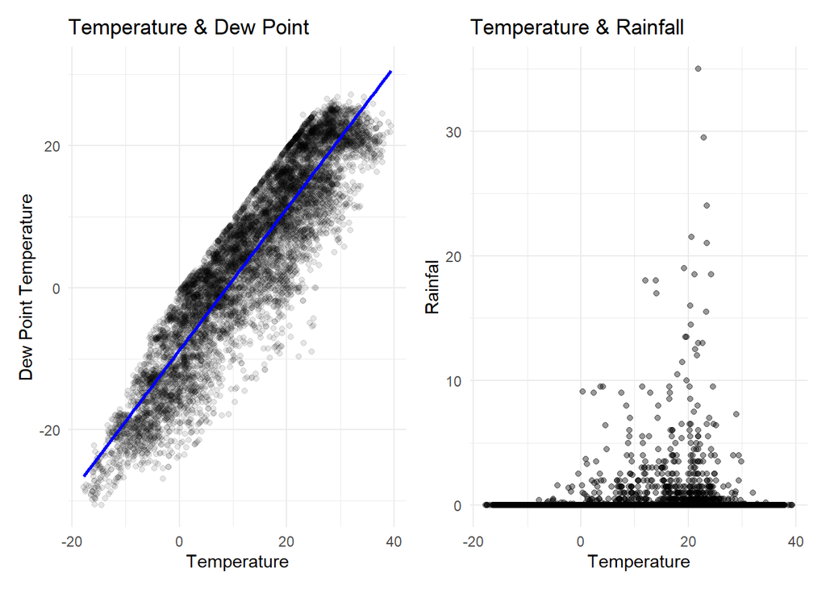

### Scatter Plot Relationship: 2

Another understandable relationship between Dew point temperature and humidity. There is a couple of outliers sitting at 0 humidity along the x axis. As expected snow only really occurring at under 0 degrees. The slightest negative relationship can be established with dew point and snowfall. Humidity has a Negative relationship with wind speed, but there is alot of noise within the relationship. Once again rainfall is struggling to make a proper connection with a different variable.

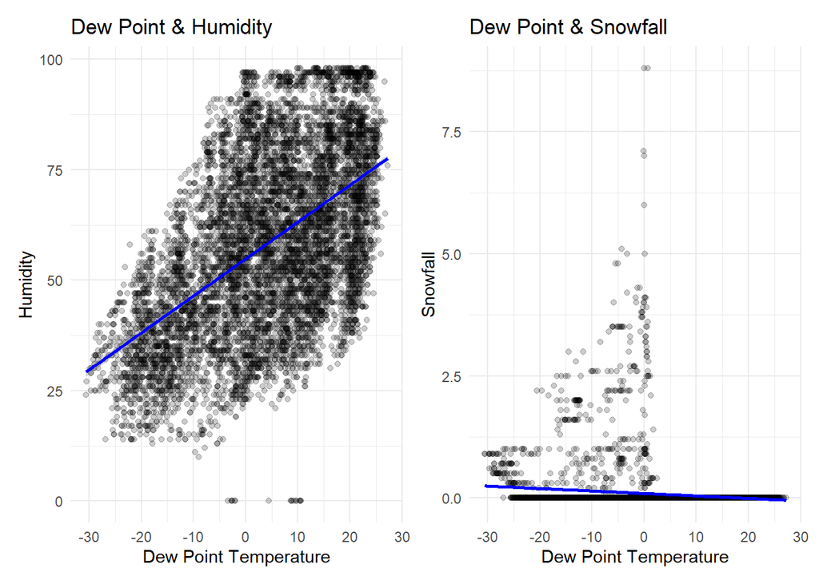

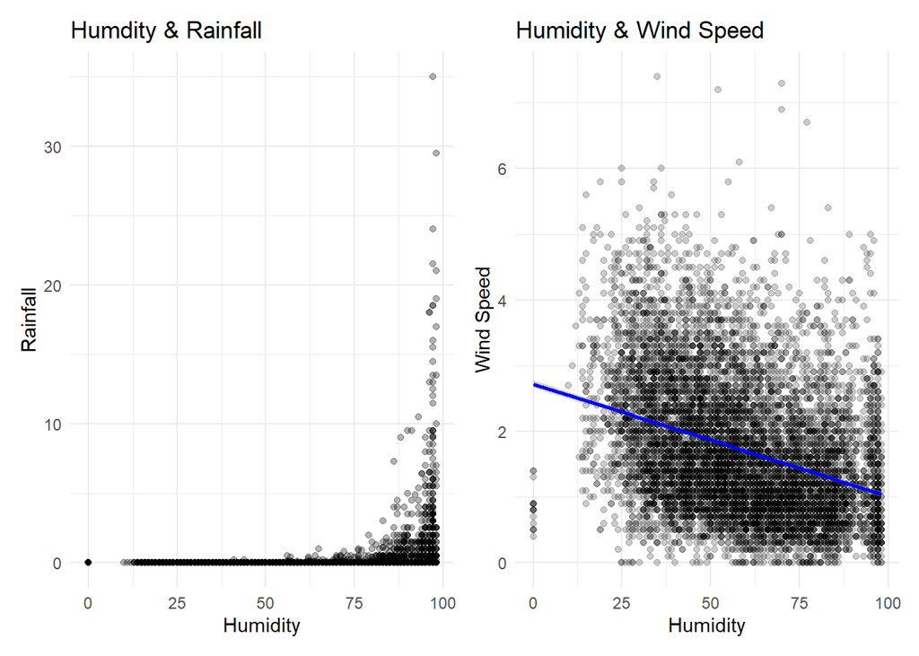

### Scatter Plot Relationship: 3

Wind speed has a complex relationship with Solar Radiation, even the confidence level is uncertain as the shading around the tail is quite thick. Though in saying that the weight of influence when it is around the tail isn’t as significant as if it was near the middle of the line but still should be noted. A very weak positive relationship between solar radiation and visibility. Visibility is somewhat in the same position as Rainfall as I’m struggling to find a good connection.  
Last ditch attempt to get a relationship established between Rainfall. I haven’t considered Snowfall but that should be linked to Season if anything. These visualisations are only suppose to get me started with understanding the relationship so I’m sure I’ll find something once I start modelling(hopefully).

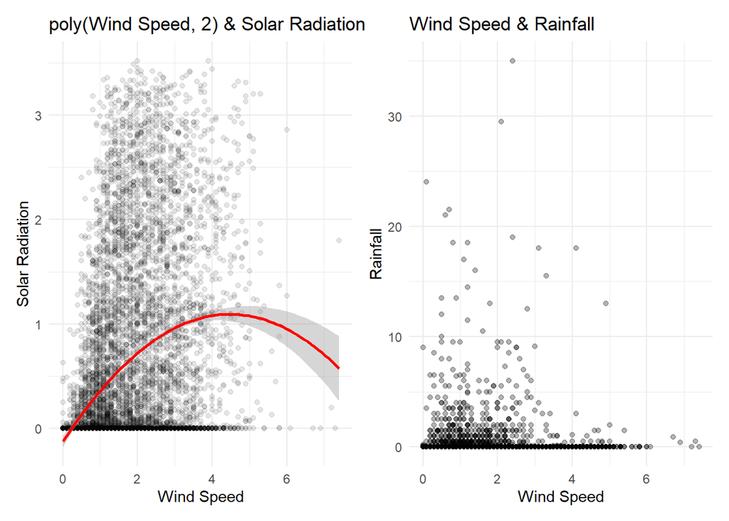

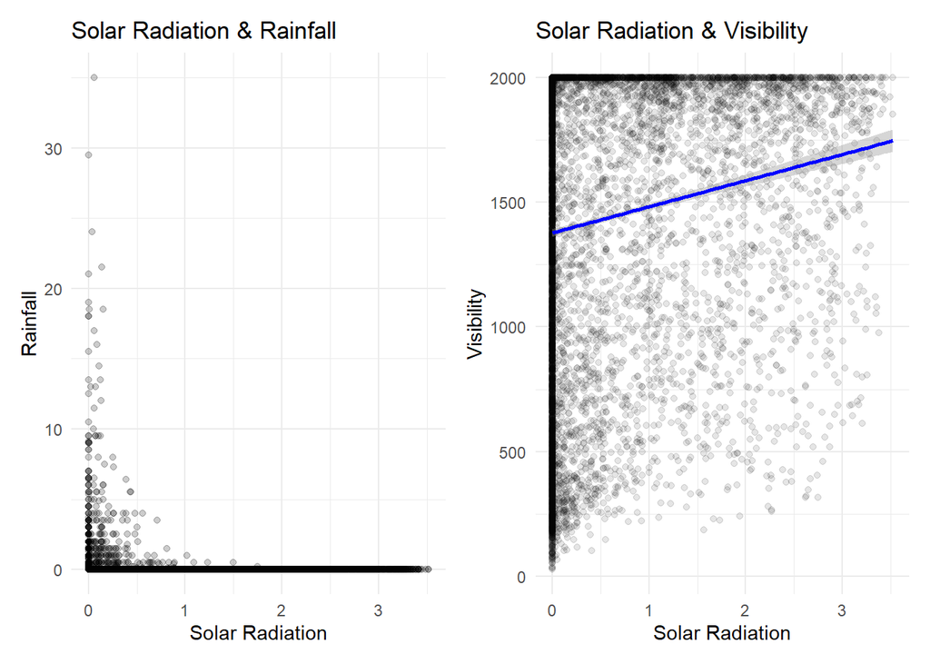

### Bar chart’s for Categorical: 1

With these bar charts, I’m less focused on the actual numbers behind the graph but more so a visual relationship these variables have with the time of day.  
Humidity, Solar radiation and Wind speed have strong relationship between the distribution and time of day. Temperature has a very generous spread across the day. Considering this. Selective pairing of these variables with time will benefit the regression alot.

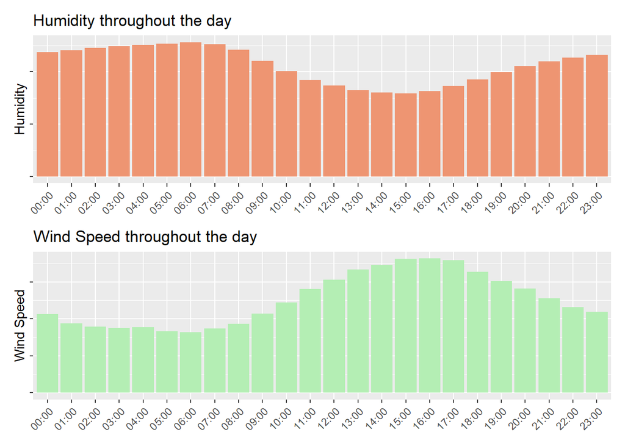

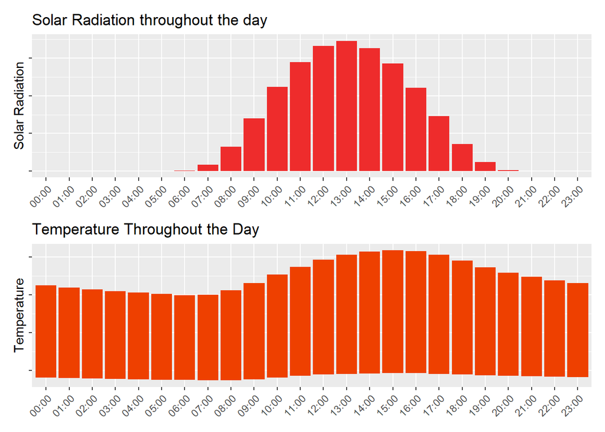

### Bar Charts for Categorical:2

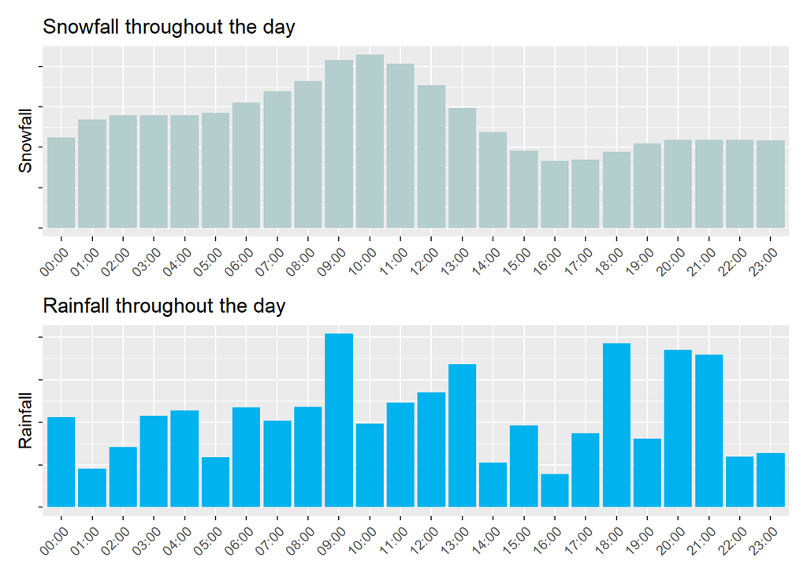

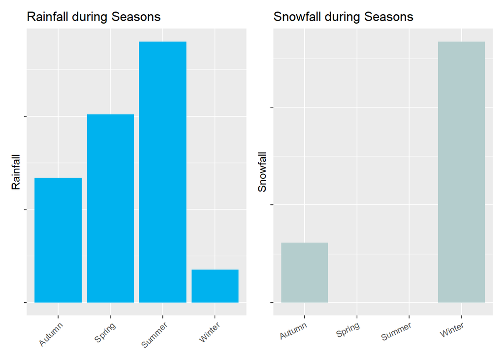

### Box plot for Categorical

These plots started out with only the first two, one being suggested by the capstone but also me trying to gauge something from Visibility. I can conclude that summer has the highest recordings of bike count and visibility is still going to be troublesome to pair with looking at the size of the boxes per hour.  
But then I noticed most outliers captured for both instances were in Autumn, curious about this I went to visualise humidity and dew point temperature and both shared the same results. I was going to assume that maybe being connected to Winter could explain the outliers but it would be safe to assume similar outlier occurrences would be seen aswell in Spring which follows Winter but not the case as Summer is the second highest in terms of outliers as visualised.

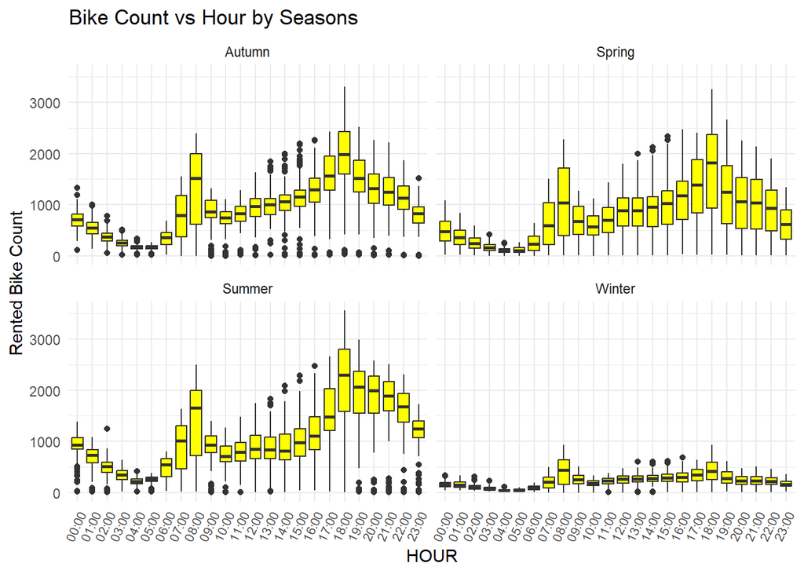

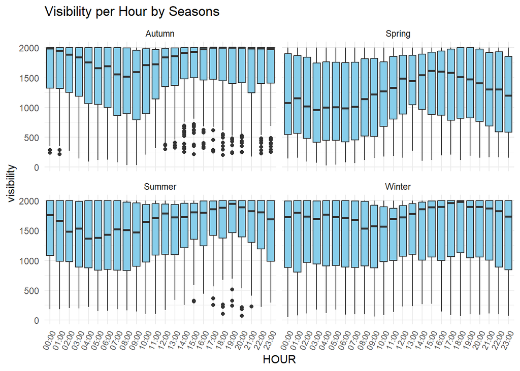

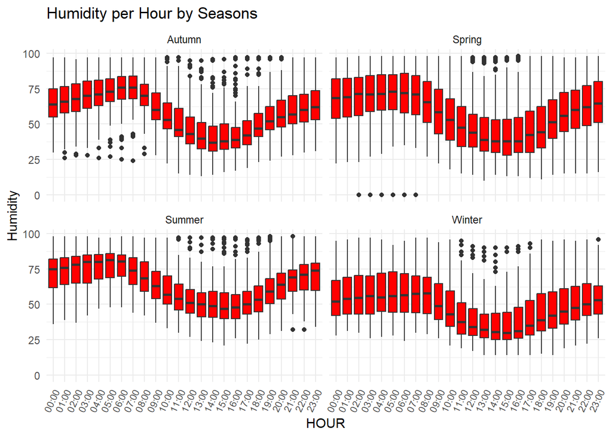

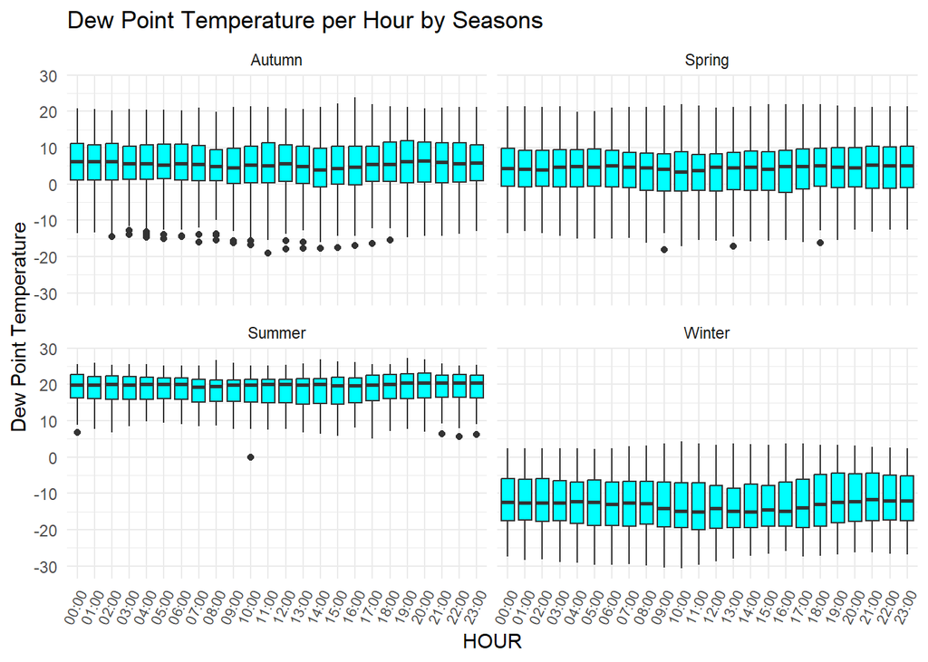

### Weather in Seoul:Forecast

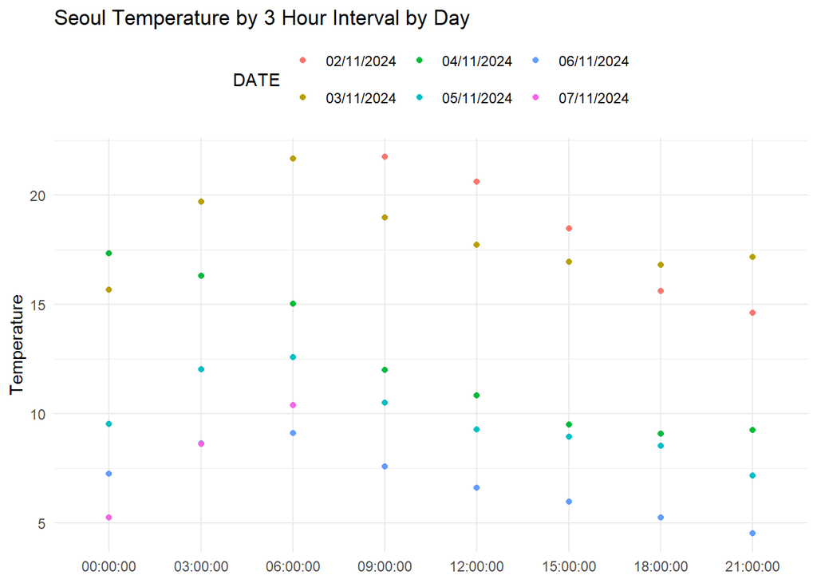

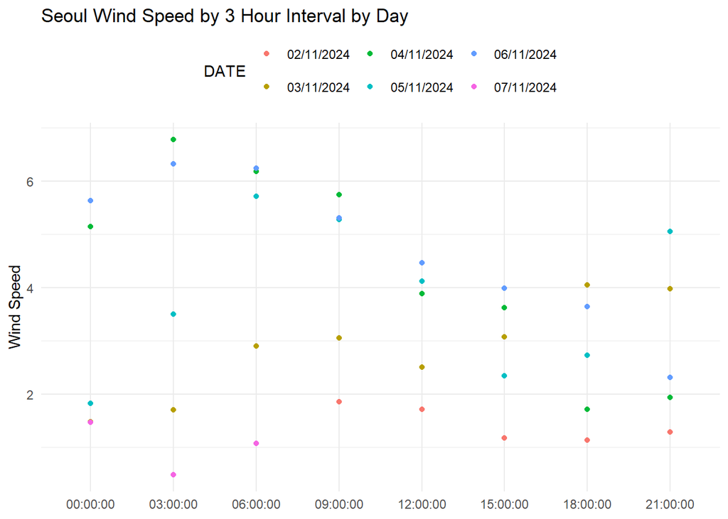

### Feels Like Temperature by Day

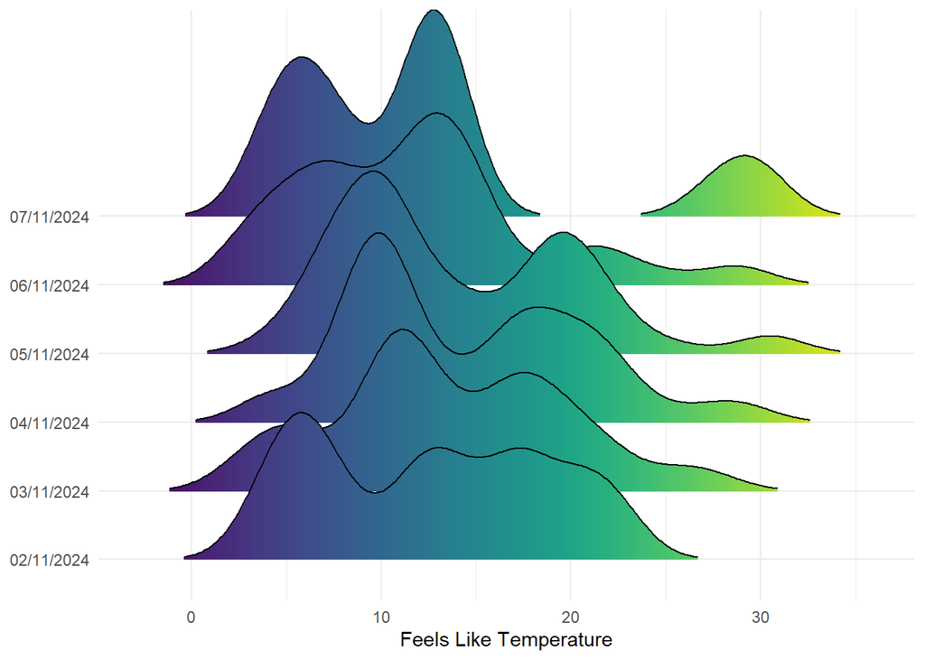

### Feels Like Temperature by City

The larger boxes for Seoul and Chicago show greater variance in the temp range. Yet both cities have the median below the middle of the box showing that majority of the distribution is lower. Looking back at the density plot it would mean all the lighter colour comes from Brisbane and an ever so small amount from Tokyo.  
Berlin, Copenhagen & Seoul contribute to majority of the dark blue, where Chicago, London & Tokyo contribute to the middle.

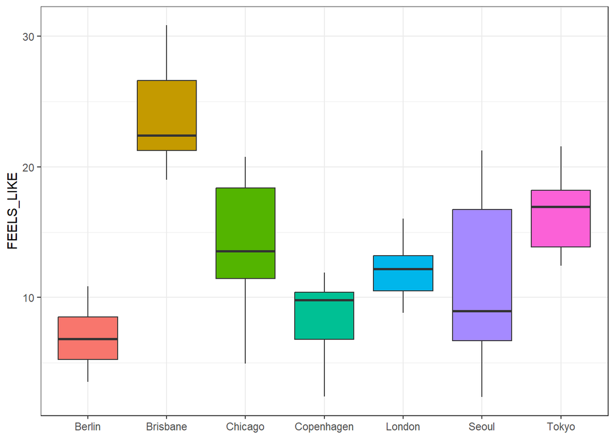

### SUMMARY

**Seoul Bike Data**  
Using the visualisations I was able to establish connections between numerous variables.  
There is have strong relationship between **Temperature** & **Dew point temperature**, I’m pretty sure I’ll establish an interaction term between the two. Considering the amount of distribution of plots in the scatter plots a lot of these relationships wont be “linear” and will require most likely polynomial terms to capture relationships & correlation.  
Humidity, Wind, solar radiation and temperature have evident trend with how it fluctuates depending on the time of day. Autumn has alot of anomalies when it comes to weather and ride count, even without completing the linear regression we have substantial information that points in the direction of weathers impact on bike sharing demand.  
**Forecast Data**  
Between the days in Seoul there is alot of recorded variance in Temperature and wind. During the distribution within the day, all days bar 4th/11/2024 show the temperature peak during 6am-12pm forming a bell like curve.  
For Wind speed there is no trend shared within the days, which might suggest other factors in play. The 4th/11/2024 records the highest wind speed at 3am-6am which so happens to be also the day that temperature doesn’t follow the trend of other days.  
Feel’s like visualisations: high variance in Seoul and Chicago with Brisbane holding majority of the temperature reading in the 20-30 category.  
Chicago, London & Tokyo hold majority of the 10-20 temperature range and Berlin Copenhagen & Seoul hold majority of the under 10 degree readings.  
It should also be noted the feel’s like box plot for Seoul has the largest Q1-Q3 sized box showing a larger distribution of feels like temperature.

## **Linear Regression**

Before building a linear regression model in R, I decided to perform a full-year review of data for Seoul within excel. This capstone didn’t have any part involving excel, but combining what I did learn about excel from this course and the Business Intelligence course it would be a waste to not practice what I learnt. I used the original raw dataset from the start & re did the cleaning using Excel’s own data cleaning techniques.  
**A couple of data cleaning techniques I performed include**:  
Season Averages: Used =AVERAGEIFS(RENTED_BIKE_COUNT, SEASONS, “season”, Hour, “hour”) to calculate seasonal hourly averages and fill in missing values.  
Time Conversion: Converted numeric hour values to time format using =TEXT((C2, “0”) & “:00”).  
Humidity Conversion: Adjusted humidity values to decimals with =E2 / 100.  
Column Alignment: corrected data types, bold headers & filling cell pacing to ensure all data is visible.  
When it comes to the dataset used in this project I actually used this data.  
During the cleaning stage it was instructed to delete NA values from the bike count column. Majority of the NA’s were in Autumn, which is the month I’m planning of doing the forecasting for. Because I didn’t want to reduce what I’m comparing my results against, I elected to use this data which places average counts in the respective time frame. This way the amount of data I’m modeling captures more influence from Autumn which will be more applicable to my forecast data.  
In my cleaning script I still completed the cleaning to IBM’s criteria and have both files, the file I will be using is titled year_ride_seoul  
**Descriptive Statistics:**  
Created mini tables to store measures such as mean, median, mode, sum, minimum, maximum, variance, and standard deviation for each season and the entire year.  
Commands used include: VAR(IF(CLAUSErange, clause, VARrange)) for variance & similiar formula’s for the other calculations.  
Created a separate worksheet with pivot tables to show some aggregations from different view points.  
Below is a snapshot of how the sheet looks, it is also available on my [github](https://github.com/PortelliA/IBM-Capstone) titled statistic_summary_seoul_data.

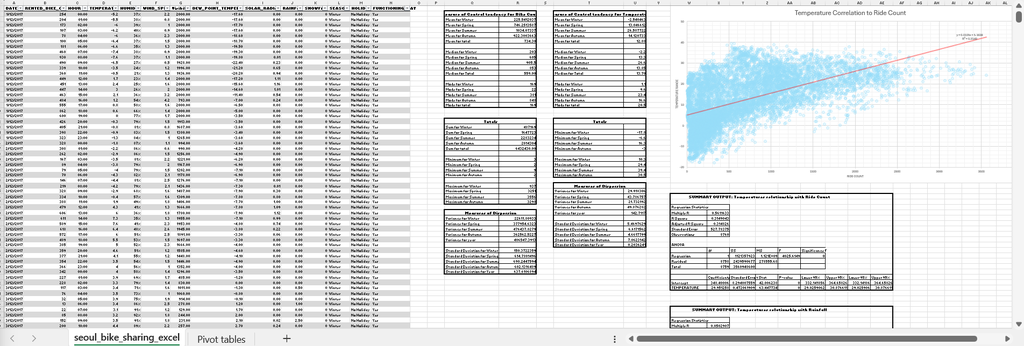

### Prepare the data

Previously for visualisation I was using the original columns, adding more to get better insights but when it comes to regression and preparing the data I’ll be converting to a more appropriate form. First I’ll normalise the data, It was suggested in the capstone to go with a min-max style, which fits the values in the 0 to 1 range.

```r
#Deleting redundant rows, suprise suprise FUNCTIONING_DAY was not going to be used
seoul_normalise<-year_ride_seoul %>%
  select(-DATE, - FUNCTIONING_DAY)
# Normalise function to scale values between 0 and 1
normalise <- function(x) {
  return((x - min(x)) / (max(x) - min(x)))
}
columns_to_normalise <- c(1, 3, 4, 5, 6, 7, 8, 9, 10)
seoul_normalise[columns_to_normalise] <- lapply(seoul_normalise[columns_to_normalise], normalise)
summary(seoul_normalise)
```

```
##  RENTED_BIKE_COUNT     HOUR            TEMPERATURE        HUMIDITY
##  Min.   :0.00000   Length:8760        Min.   :0.0000   Min.   :0.0000
##  1st Qu.:0.06078   Class :character   1st Qu.:0.3724   1st Qu.:0.4286
##  Median :0.15672   Mode  :character   Median :0.5507   Median :0.5816
##  Mean   :0.20604                      Mean   :0.5365   Mean   :0.5941
##  3rd Qu.:0.30670                      3rd Qu.:0.7045   3rd Qu.:0.7551
##  Max.   :1.00000                      Max.   :1.0000   Max.   :1.0000
##    WIND_SPEED       VISIBILITY     DEW_POINT_TEMPERATURE SOLAR_RADIATION
##  Min.   :0.0000   Min.   :0.0000   Min.   :0.0000        Min.   :0.000000
##  1st Qu.:0.1216   1st Qu.:0.4627   1st Qu.:0.4481        1st Qu.:0.000000
##  Median :0.2027   Median :0.8469   Median :0.6176        Median :0.002841
##  Mean   :0.2331   Mean   :0.7146   Mean   :0.5999        Mean   :0.161679
##  3rd Qu.:0.3108   3rd Qu.:1.0000   3rd Qu.:0.7855        3rd Qu.:0.264205
##  Max.   :1.0000   Max.   :1.0000   Max.   :1.0000        Max.   :1.000000
##     RAINFALL           SNOWFALL         SEASONS            HOLIDAY
##  Min.   :0.000000   Min.   :0.00000   Length:8760        Length:8760
##  1st Qu.:0.000000   1st Qu.:0.00000   Class :character   Class :character
##  Median :0.000000   Median :0.00000   Mode  :character   Mode  :character
##  Mean   :0.004248   Mean   :0.00853
##  3rd Qu.:0.000000   3rd Qu.:0.00000
##  Max.   :1.000000   Max.   :1.00000
```

**observations to make from this conversion**  
Visibility and Dew Point Temperature: Both have similar skewness towards the maximum, suggesting a potential pairing where polynomial transformations might capture their relationship well.  
Humidity and Dew Point Temperature: Both have high means and similar distributions, indicating they could interact meaningfully in the model.  
Temperature and Solar Radiation: With their means and ranges, they might work well together.  
Rainfall and Wind Speed: Both show lower variability but I’ll test the interactions with higher-order polynomials.  
**One-hot Encoding** - a method to divide a categorical column into individual columns broken down by each of the distinct observations and turning them into a binary answer of 1 and 0 (yes and no), consider it like pivot long but without affecting the amount of rows. This helps deal with false ordinality, when it comes to seasons, holidays & hour’s, they shouldn’t be ranked.

```r
cols <- c("SEASONS", "HOLIDAY", "HOUR")
# Function to create dummy variables
create_dummy_vars <- function(data, cols) {
  for (col in cols) {
    data <- data %>%
      mutate(dummy = 1) %>%
      spread(key = col, value = dummy, fill = 0)
  }
  return(data)
}
# Apply the function to the dataset
seoul_normalise <- create_dummy_vars(seoul_normalise, cols)
```

**Time to split the dataset to testing and training**

```r
set.seed(42)
bike_sharing_split <- initial_split(seoul_normalise, prop = 0.75)
seoultrain <- training(bike_sharing_split)
seoultest <- testing(bike_sharing_split)
```

Just like sports, all the work goes in during training, while I explore the data and try create the best model possible I have to be able to measure it against itself before the training begun.

### Regression

**Create two models, one with all variables included, the other with all weather related variables**

```r
lm_model_all <- linear_reg(mode = "regression", engine = "lm") %>%
  fit(RENTED_BIKE_COUNT ~ ., data = seoultrain)
# model above has all variables inside, while the one below has only weather related
lm_model_weather <- linear_reg(mode = "regression", engine = "lm") %>%
  fit(RENTED_BIKE_COUNT ~ TEMPERATURE + HUMIDITY + WIND_SPEED + VISIBILITY +
                          DEW_POINT_TEMPERATURE + SOLAR_RADIATION + RAINFALL + SNOWFALL, data = seoultrain)
# Make predictions on the test set using lm_model_all
predictions_all <- predict(lm_model_all, new_data = seoultest)
# Make predictions on the test set using lm_model_weather
predictions_weather <- predict(lm_model_weather, new_data = seoultest)
# Place truth columns inside
prediction_all <- data.frame( TRUTH = seoultest$RENTED_BIKE_COUNT, predictions_all = predictions_all$.pred )
prediction_weather <- data.frame( TRUTH = seoultest$RENTED_BIKE_COUNT, predictions_weather = predictions_weather$.pred )
```

**Use rsq() and rmse() functions to calculate R-squared and RMSE metrics for the two test results**  
When it comes to goals of a regression, there are other metrics to consider but two important ones are the RMSE & R-Squared.  
Root Mean Standard Error is a measure of a model’s overall accuracy. It compares the model’s predicted values to the actual values, specifically looking at the residuals (the differences between predicted and actual values). RMSE is a good indication of how well the model captures the relationship between the dependent variable and the independent variables introduced in the model. Lower RMSE values indicate a better fit, seeing as the data is scaled from 0 - 1, I want to aim for under 10pct which would be 0.1  
R-Squared is the measure that explains how much influence the independent variables have on the dependant variables, in this case, how much influence does weather have on rented bike counts. It ranges from 0 to 1, where 0 indicates that the model does not explain any of the variance in the dependent variable, and 1 indicates that the model explains all the variance. The capstone suggests 0.72 but I’ll aim higher

```r
# Calculate R-squared for weather model
rsq_weather <- rsq(data = prediction_weather, truth = TRUTH, estimate = predictions_weather)
rsq_weather
```

```
## # A tibble: 1 × 3
##   .metric .estimator .estimate
##   <chr>   <chr>          <dbl>
## 1 rsq     standard       0.428
```

```r
# Calculate RMSE for weather model
rmse_weather <- rmse(data = prediction_weather, truth = TRUTH, estimate = predictions_weather)
rmse_weather
```

```
## # A tibble: 1 × 3
##   .metric .estimator .estimate
##   <chr>   <chr>          <dbl>
## 1 rmse    standard       0.133
```

```r
# Calculate R-squared for all variables model
rsq_all <- rsq(data = prediction_all, truth = TRUTH, estimate = predictions_all)
rsq_all
```

```
## # A tibble: 1 × 3
##   .metric .estimator .estimate
##   <chr>   <chr>          <dbl>
## 1 rsq     standard       0.656
```

```r
# Calculate RMSE for all variables model
rmse_all <- rmse(data = prediction_all, truth = TRUTH, estimate = predictions_all)
rmse_all
```

```
## # A tibble: 1 × 3
##   .metric .estimator .estimate
##   <chr>   <chr>          <dbl>
## 1 rmse    standard       0.103
```

**Its clear lm_model_all is better, now to rank the coefficients in that dataset**

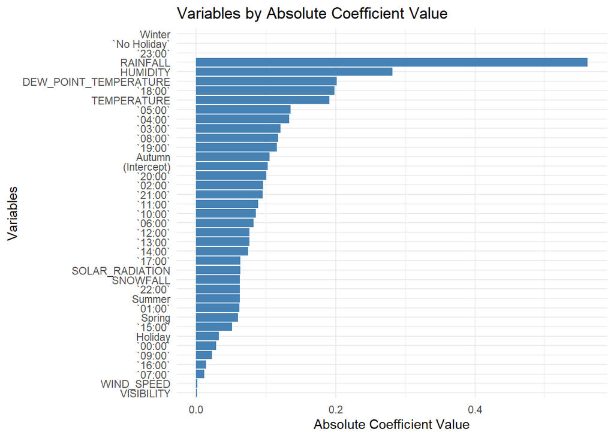

```r
# Extract coefficients from the lm_model_all
lm_model_all %>%
  tidy() %>%
  arrange(desc(abs(estimate))) %>%
ggplot(aes(x = reorder(term, abs(estimate)), y = abs(estimate))) +
  geom_bar(stat = "identity", fill = "steelblue") +
  coord_flip() +
  labs(title = "Variables by Absolute Coefficient Value", x = "Variables", y = "Absolute Coefficient Value") +
  theme(axis.text.y = element_text(size = 4))+
  theme_minimal()
```

### Polynomial Regression

When it comes to Polynomial regression, I interpret it with the example of travelling from point(a) to point(b). Where a SLR is a straight path that gets you to point(b) by going in one straight direction, like a highway. As you travel along the highway you might see in the distance objects in the landscape that you cant explain.  
While polynomial is the thought you can get to the same point(b) but instead of going straight to point (b), you along the way pull into a different road(lets consider a scenic path by the river which in most cases loops back onto the main road) which allows you to get a better understanding of the landscape. While scenic path might explain the landscape to which you are travelling, the potential trade off of adding flexibility is complexity and a larger margin of potential misinterpretation(residual/noise).  
**Model Refinement**  
When I initially plotted the relationship between rented bike count and temperature, I couldn’t detect a curved polynomial (degree 2) trend. However, after standardizing the data, the variances are now better uniform, making the underlying relationships between variables more visible. The model below shows a standard `lm_line` in red, `poly(x,2)` in yellow, `poly(x,4)` in green & `poly(x,6)` in blue.

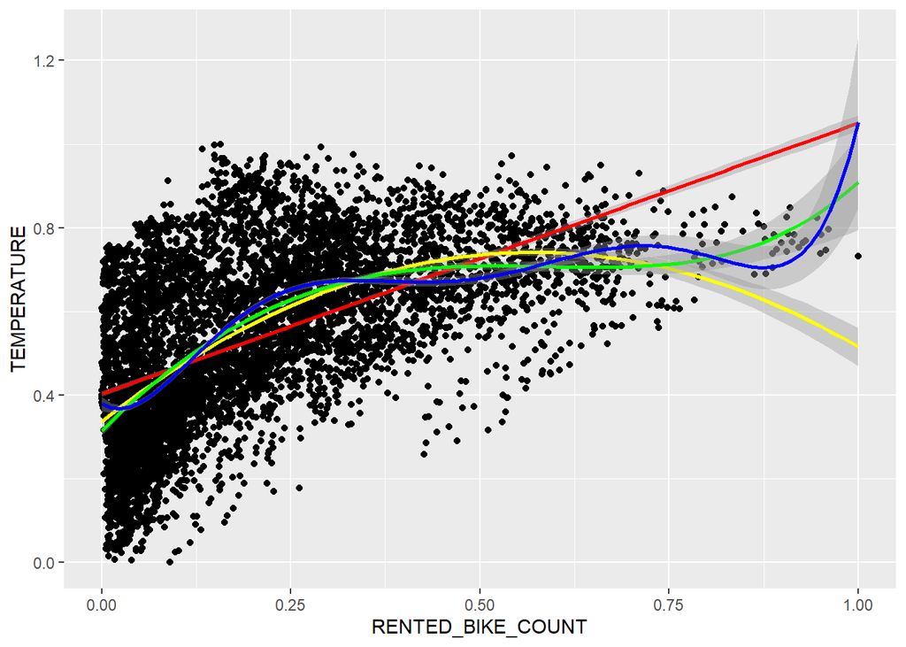

**Fit a linear regression model `lm_poly` with higher order polynomial terms on the important variables (larger coefficients) found in the baseline model**

```r
# Fit the polynomial regression model
lm_poly <- linear_reg(mode = "regression", engine = "lm") %>%
  fit(RENTED_BIKE_COUNT ~ . + poly(TEMPERATURE, 6) + poly(HUMIDITY, 6) + poly(DEW_POINT_TEMPERATURE, 4) + poly(RAINFALL, 4), data = seoultrain)
predictions_poly<- predict(lm_poly, new_data = seoultest)
prediction_poly <- data.frame( TRUTH = seoultest$RENTED_BIKE_COUNT, predictions_all = predictions_all$.pred )
```

```r
# Calculate R-squared for poly model
rsq_poly <- rsq(data = prediction_poly, truth = TRUTH, estimate = predictions_all)
rsq_poly
```

```
## # A tibble: 1 × 3
##   .metric .estimator .estimate
##   <chr>   <chr>          <dbl>
## 1 rsq     standard       0.656
```

```r
# Calculate RMSE for poly model
rmse_poly <- rmse(data = prediction_poly, truth = TRUTH, estimate = predictions_all)
rmse_poly
```

```
## # A tibble: 1 × 3
##   .metric .estimator .estimate
##   <chr>   <chr>          <dbl>
## 1 rmse    standard       0.103
```

### Adding interaction terms

```r
# Fit the polynomial regression model lm_poly1
lm_poly1 <- linear_reg(mode = "regression", engine = "lm") %>%
  fit(RENTED_BIKE_COUNT ~ . + poly(TEMPERATURE, 4) * poly(DEW_POINT_TEMPERATURE, 2) + Autumn * `18:00` + Autumn * Holiday + poly(HUMIDITY,4) * `19:00` + poly(SOLAR_RADIATION, 2) * `12:00`, data = seoultrain)
predictions_poly1 <- predict(lm_poly1, new_data = seoultest)
prediction_poly1 <- data.frame(
  TRUTH = seoultest$RENTED_BIKE_COUNT,
  predictions_poly1 = predictions_poly1$.pred
)
summary(lm_poly1$fit)
```

```
##
## Call:
## stats::lm(formula = RENTED_BIKE_COUNT ~ . + poly(TEMPERATURE,
##     4) * poly(DEW_POINT_TEMPERATURE, 2) + Autumn * `18:00` +
##     Autumn * Holiday + poly(HUMIDITY, 4) * `19:00` + poly(SOLAR_RADIATION,
##     2) * `12:00`, data = data)
##
## Residuals:
##      Min       1Q   Median       3Q      Max
## -0.39379 -0.05280  0.00194  0.04907  0.42375
##
## Coefficients: (7 not defined because of singularities)
##                                                         Estimate Std. Error
## (Intercept)                                            5.365e-02  1.656e-01
## TEMPERATURE                                            4.055e-01  3.676e-01
## HUMIDITY                                              -4.835e-03  1.012e-01
## WIND_SPEED                                            -1.583e-02  9.591e-03
## VISIBILITY                                            -5.932e-03  4.984e-03
## DEW_POINT_TEMPERATURE                                 -1.836e-01  2.533e-01
## SOLAR_RADIATION                                        6.497e-02  1.192e-02
## RAINFALL                                              -2.628e-01  3.754e-02
## SNOWFALL                                              -5.993e-02  2.530e-02
## Autumn                                                 9.953e-02  5.709e-03
## Spring                                                 6.240e-02  5.579e-03
## Summer                                                 9.767e-02  7.231e-03
## Winter                                                        NA         NA
## Holiday                                               -1.563e-02  6.187e-03
## `No Holiday`                                                  NA         NA
## `00:00`                                               -3.162e-02  7.688e-03
## `01:00`                                               -6.249e-02  7.740e-03
## `02:00`                                               -9.848e-02  7.681e-03
## `03:00`                                               -1.223e-01  7.700e-03
## `04:00`                                               -1.355e-01  7.799e-03
## `05:00`                                               -1.380e-01  7.911e-03
## `06:00`                                               -8.689e-02  7.760e-03
## `07:00`                                               -3.277e-03  7.913e-03
## `08:00`                                                8.391e-02  7.986e-03
## `09:00`                                               -6.387e-02  8.732e-03
## `10:00`                                               -1.194e-01  9.187e-03
## `11:00`                                               -1.060e-01  9.332e-03
```

[output cut: 99 more lines]

```
## poly(TEMPERATURE, 4)4:poly(DEW_POINT_TEMPERATURE, 2)2   5.339 9.64e-08 ***
## Autumn:`18:00`                                          6.724 1.92e-11 ***
## Autumn:Holiday                                         -4.223 2.44e-05 ***
## `19:00`:poly(HUMIDITY, 4)1                             -3.566 0.000365 ***
## `19:00`:poly(HUMIDITY, 4)2                             -6.068 1.37e-09 ***
## `19:00`:poly(HUMIDITY, 4)3                             -3.465 0.000533 ***
## `19:00`:poly(HUMIDITY, 4)4                              3.294 0.000991 ***
## `12:00`:poly(SOLAR_RADIATION, 2)1                      -1.289 0.197559
## `12:00`:poly(SOLAR_RADIATION, 2)2                       2.317 0.020532 *
## ---
## Signif. codes:  0 '***' 0.001 '**' 0.01 '*' 0.05 '.' 0.1 ' ' 1
##
## Residual standard error: 0.08922 on 6510 degrees of freedom
## Multiple R-squared:  0.7586, Adjusted R-squared:  0.7564
## F-statistic: 346.7 on 59 and 6510 DF,  p-value: < 2.2e-16
```

I waited til now to display the summary of a regression model as this captures everything I have learnt throughout this course, its a huge block of figures but it shows what each important factor to consider when looking at a regression model  
Near the bottom of the summary in the coeffiecients there is text that looks like  
`poly(TEMPERATURE, 4)1:poly(DEW_POINT_TEMPERATURE, 2)1`  
`poly(TEMPERATURE, 4)2:poly(DEW_POINT_TEMPERATURE, 2)1`  
`poly(TEMPERATURE, 4)3:poly(DEW_POINT_TEMPERATURE, 2)1`  
`poly(TEMPERATURE, 4)4:poly(DEW_POINT_TEMPERATURE, 2)1`  
`poly(TEMPERATURE, 4)1:poly(DEW_POINT_TEMPERATURE, 2)2`  
`poly(TEMPERATURE, 4)2:poly(DEW_POINT_TEMPERATURE, 2)2`  
`poly(TEMPERATURE, 4)3:poly(DEW_POINT_TEMPERATURE, 2)2`  
`poly(TEMPERATURE, 4)4:poly(DEW_POINT_TEMPERATURE, 2)2`  
This shows how polynomial & interaction terms work in regression, first if we look at the first line were it shows the interaction(this is at the first degree or the straight line relationship of both Temperature and dew point) between both independent variables, then on the following 3 lines its looking at temperatures higher degree against dew points first degree, then it restarts the poly term for temperature but looks at the second degree for dew point.  
Going back to my half cooked analogy about taking the scenic drive by the river to get to point B & seeing the landscape which you couldn’t by taking the highway.  
The different landscapes might have features that are related to one another like how the river supplies water for the animals in the area, you might see an animal drinking water from the river. That would be an interaction, you could see the animal not by the river 100% but now you know how it relates to to the river which gives you a better understanding of what you are seeing. I just made my half cooked analogy fully cooked I apologise.  
Now looking at the top of the summary we have a residual range.  
Residuals are the differences between the observed values and the predicted values from the model. They help us understand how well the model fits the data. Ideally, residuals should be randomly distributed with a mean of zero, indicating that the model’s predictions are accurate on average. Residual analysis can reveal patterns that suggest potential problems in the model, such as non-linearity, heteroscedasticity or outliers.

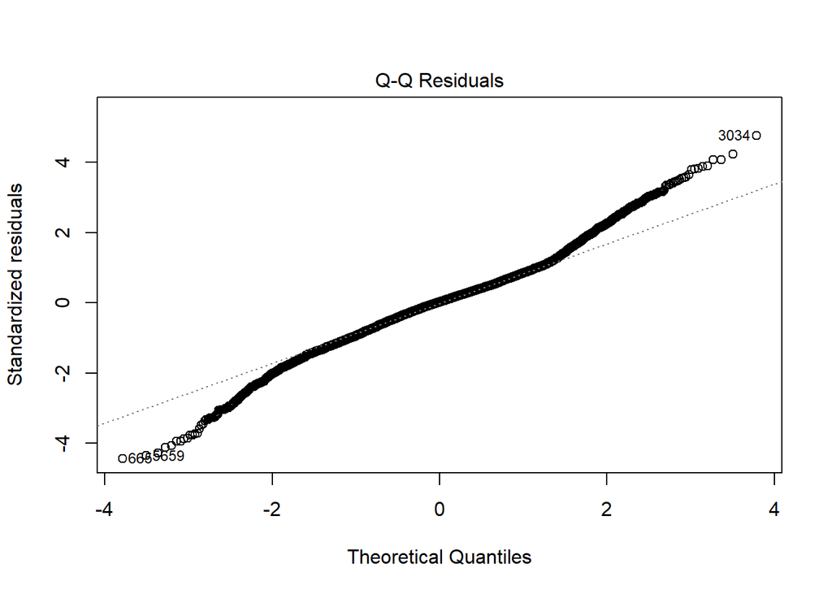

```r
plot(lm_poly1$fit, which = 2, sub.caption = "")
```

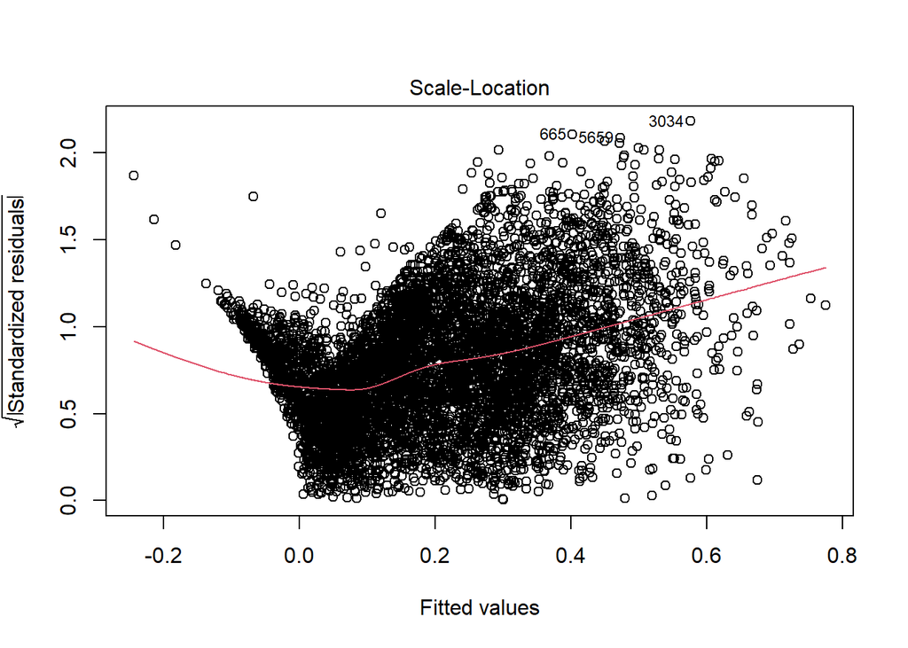

```r
plot(lm_poly1$fit, which = 3, sub.caption = "")
```

The scale location plot is a great way to check heteroscedasticity. In simpler terms, heteroscedasticity is an assumption that the model’s errors are consistently spread out across all predictions. Ideally, the errors (residuals) should be evenly scattered, indicating a constant variance.  
In the Scale-Location plot, you’re looking at how well the model meets this requirement. The plot shows the fitted values on the X-axis and the spread of the residuals on the Y-axis.  
If the red line in your plot dips at any point, it suggests that the residuals are not evenly spread out and that there are areas where the variance of errors is lower. So this model fails the heteroscedasticity assumption.

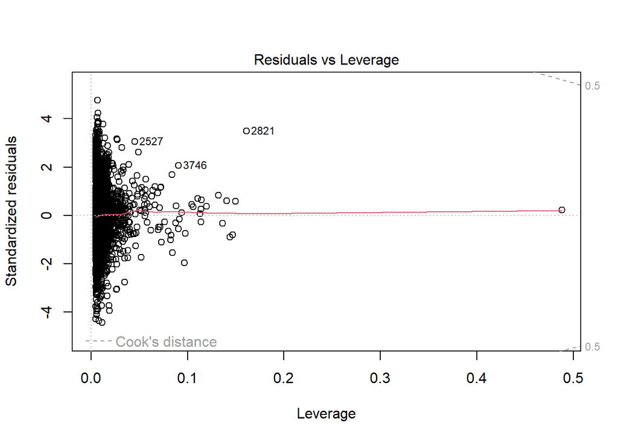

```r
plot(lm_poly1$fit, which = 5, sub.caption = "")
```

This plot helps identify points that might have a big impact on the regression. Firstly most data points are clustered near the 0.0 mark on the x axis and within the -4 to 4 range on the y-axis.  
Then we have the 4 dash line starting on the 0 intercept of the x and y axis which is cooks distance.  
So the cooks distance is something that was briefly covered by Equitable Equations in his video on outliers as a means to identify high influence anomalies & determine if they should be removed.  
In the video, he uses two side by side scatter plots with a regression line each with an outlier that to the naked eye could be perceived as a significant outlier. But he includes a second differently coloured regression line to show the difference when the outlier is removed from the dataset. One shows a great improvement to the regression line while the other doesn’t. He ends by stating this method being cooks distance is the way you can visualise it without that side by side comparison.  
Not being a perfect model or anywhere close, but there is alot of outliers that the model is capturing.

```r
# Calculate R-squared for poly model
rsq_poly1 <- rsq(data = prediction_poly1, truth = TRUTH, estimate = predictions_poly1)
rsq_poly1
```

```
## # A tibble: 1 × 3
##   .metric .estimator .estimate
##   <chr>   <chr>          <dbl>
## 1 rsq     standard       0.748
```

```r
# Calculate RMSE for poly model
rmse_poly1 <- rmse(data = prediction_poly1, truth = TRUTH, estimate = predictions_poly1)
rmse_poly1
```

```
## # A tibble: 1 × 3
##   .metric .estimator .estimate
##   <chr>   <chr>          <dbl>
## 1 rmse    standard      0.0881
```

### Tuning of Lambda to find the best fit

Within the 3 regression models of Ridge, lasso and elastic net that I’m going to be exploring, the technique of tuning the lambda is different between the models by the method of how it deals with shrinking the regressions coefficients, helping reduce the models complexity & enhancing generalisation to the data.  
**Ridge**: Applies a penalty to all coefficients evenly, ideal for addressing multi collinearity.  
**Lasso**: Shrinks some coefficients to zero, effectively selecting key features and discarding irrelevant ones.  
**Elastic Net**: Combines both penalties, offering a balanced approach that benefits from the strengths of both Ridge and Lasso.  
**Build different models using polynomial terms, interaction terms, and regularizations.**

```r
# This is the poly_model1 formula from above, lets see how it does with some tuning
lm_glmnet_formula1 <- formula(RENTED_BIKE_COUNT ~ . +
                                poly(TEMPERATURE, 4) * poly(DEW_POINT_TEMPERATURE, 2) +
                                Autumn * `18:00` +
                                Autumn * Holiday +
                                poly(HUMIDITY, 4) * `19:00` +
                                poly(SOLAR_RADIATION, 2) * `12:00`)
# Create cross-validation folds
set.seed(42)
folds <- vfold_cv(seoultrain, v = 10)

# Define the model with tuning parameters, have to create this but wont need to replicate every time
tune_time <- linear_reg(penalty = tune(), mixture = tune()) %>%
  set_engine("glmnet")

# Define the workflow
wf <- workflow() %>%
  add_formula(lm_glmnet_formula1)

# Create the tuning grid, I only have to make this initially, once I make more models no need. The Lambda grid is stating the range of penalty I want to apply, so starting at 0% to 20%. The mixture is the different style of Lambda
lambda_grid <- seq(0, 0.2, length.out = 25)
mixture_grid <- seq(0, 1, length.out = 25)
tuning_grid <- expand.grid(penalty = lambda_grid, mixture = mixture_grid)

# Tune the model using the grid
suppressWarnings({grid_results1 <- tune_grid(
  wf %>% add_model(tune_time),
  resamples = folds,
  grid = tuning_grid,
  metrics = metric_set(rmse, rsq))
})
```

[output not shown]

[output not shown]

```r
# Display the top result based on RMSE
show_best(grid_results1, metric = "rmse")
```

```
## # A tibble: 5 × 8
##   penalty mixture .metric .estimator   mean     n std_err .config
##     <dbl>   <dbl> <chr>   <chr>       <dbl> <int>   <dbl> <chr>
## 1       0  0.417  rmse    standard   0.0896    10 0.00102 Preprocessor1_Model251
## 2       0  0.0417 rmse    standard   0.0896    10 0.00102 Preprocessor1_Model026
## 3       0  0.75   rmse    standard   0.0896    10 0.00102 Preprocessor1_Model451
## 4       0  0.917  rmse    standard   0.0896    10 0.00102 Preprocessor1_Model551
## 5       0  0.958  rmse    standard   0.0896    10 0.00102 Preprocessor1_Model576
```

```r
best_grid1 <- select_best(grid_results1, metric = "rmse")
final_wf1 <- finalize_workflow(wf %>% add_model(tune_time),
                              best_grid1)
final_fit1 <-fit(final_wf1, data = seoultrain)
predictions1 <- predict(final_fit1, new_data = seoultest)
# The capstone suggested that I make all predicted scores that are under 0 actually 0 because we cant have negative ride count.
predictions_df1 <- seoultest %>%
  mutate(predicted = ifelse(predictions1$.pred < 0, 0, predictions1$.pred), residuals = RENTED_BIKE_COUNT - predicted)
rmse_final1 <- rmse(data = predictions_df1, truth = RENTED_BIKE_COUNT, estimate = predicted)
rmse_final1
```

```
## # A tibble: 1 × 3
##   .metric .estimator .estimate
##   <chr>   <chr>          <dbl>
## 1 rmse    standard      0.0861
```

```r
rsq_final1 <- rsq(data = predictions_df1, truth = RENTED_BIKE_COUNT, estimate = predicted)
rsq_final1
```

```
## # A tibble: 1 × 3
##   .metric .estimator .estimate
##   <chr>   <chr>          <dbl>
## 1 rsq     standard       0.760
```

```r
# this one is inspired by the categorical data visualisations I made
lm_glmnet_formula2 <- formula(RENTED_BIKE_COUNT ~ . +
                                poly(TEMPERATURE,6) * poly(DEW_POINT_TEMPERATURE,4)+
                                Autumn * Holiday +Summer * `18:00` +
                                poly(TEMPERATURE, 6) * poly(HUMIDITY, 4) +
                                  poly(SOLAR_RADIATION, 4) * `12:00`+
                                  poly(SNOWFALL,2)* Winter +
                                  poly(RAINFALL, 4) * `20:00` +
                                  poly(HUMIDITY, 4) * poly(DEW_POINT_TEMPERATURE, 4) +
                                Winter * poly(VISIBILITY,4))

wf2 <- workflow() %>%
  add_formula(lm_glmnet_formula2)
suppressWarnings({grid_results2 <- tune_grid(
  wf2 %>% add_model(tune_time),
  resamples = folds,
  grid = tuning_grid,
  metrics = metric_set(rmse,rsq))
})
```

[output not shown]

[output not shown]

```r
show_best(grid_results2, metric = "rmse")
```

```
## # A tibble: 5 × 8
##   penalty mixture .metric .estimator   mean     n std_err .config
##     <dbl>   <dbl> <chr>   <chr>       <dbl> <int>   <dbl> <chr>
## 1       0  0.0833 rmse    standard   0.0894    10 0.00160 Preprocessor1_Model051
## 2       0  0.0417 rmse    standard   0.0895    10 0.00165 Preprocessor1_Model026
## 3       0  0.125  rmse    standard   0.0895    10 0.00165 Preprocessor1_Model076
## 4       0  0.25   rmse    standard   0.0895    10 0.00166 Preprocessor1_Model151
## 5       0  0.167  rmse    standard   0.0895    10 0.00167 Preprocessor1_Model101
```

```r
best_grid2 <- select_best(grid_results2, metric = "rmse")
final_wf2 <- finalize_workflow(wf2 %>% add_model(tune_time),
                              best_grid2)
final_fit2 <-fit(final_wf2, data = seoultrain)
predictions2 <- predict(final_fit2, new_data = seoultest)
#You can gauge from the "mean" in the table above roughly what your RMSE is going to be, the penatly applied is still 0 though
predictions_df2 <- seoultest %>%
  mutate(predicted = ifelse(predictions2$.pred < 0, 0, predictions2$.pred), residuals = RENTED_BIKE_COUNT - predicted)
rmse_final2 <- rmse(data = predictions_df2, truth = RENTED_BIKE_COUNT, estimate = predicted)
rmse_final2
```

```
## # A tibble: 1 × 3
##   .metric .estimator .estimate
##   <chr>   <chr>          <dbl>
## 1 rmse    standard      0.0844
```

```r
rsq_final2 <- rsq(data = predictions_df2, truth = RENTED_BIKE_COUNT, estimate = predicted)
rsq_final2
```

```
## # A tibble: 1 × 3
##   .metric .estimator .estimate
##   <chr>   <chr>          <dbl>
## 1 rsq     standard       0.769
```

Still not the results I’m looking for, this was a technique covered well in IBM course, being Pearson’s Correlation coefficient, previously I was using visualisation to try capture the relationship between variables which 100% gave me strong evidence.

```r
correlation_matrix <- cor(seoul_normalise, method = "pearson")
```

**Pearson’s Correlation Coefficient**  
With this table I’m not going to display what it looks like, as it is just as large as that poly/interaction model summary above. The method is a formula to see relationship between variables between 1 and -1. 1 being 100% positive correlation(when one thing increase the other does) and -1 being a 100% negative correlation(when one goes down so does the other). So the sweet spot is more than 0.5 and less than -0.5 within the range. From there I found a couple of strong relationships being:  
Humidity & visibility, temperature & Winter, Solar Radiation and 12:00 & Dew_Point_temperature with winter/Summer

```r
lm_glmnet_formula3 <- formula(RENTED_BIKE_COUNT ~ . +
                                poly(TEMPERATURE,6) +
                                DEW_POINT_TEMPERATURE * Winter +
                                DEW_POINT_TEMPERATURE * Summer +
                                DEW_POINT_TEMPERATURE * TEMPERATURE +
                                TEMPERATURE * Winter +
                                poly(SNOWFALL, 4) * TEMPERATURE +
                                poly(HUMIDITY, 4) * poly(DEW_POINT_TEMPERATURE, 2) +
                                Summer * `18:00` + Autumn * Holiday +
                                poly(HUMIDITY, 4) * poly(VISIBILITY,2) +
                                Autumn * `18:00` + TEMPERATURE * `05:00` +
                                poly(RAINFALL, 4) * poly(WIND_SPEED, 2))

  wf3 <- workflow() %>%
    add_formula(lm_glmnet_formula3)
 suppressWarnings({grid_results3 <- tune_grid(wf3 %>% add_model(tune_time),
                             resamples = folds,
                             grid = tuning_grid,
                             metrics = metric_set(rmse, rsq))
 })
```

[output not shown]

[output not shown]

```r
show_best(grid_results3, metric = "rmse")
```

```
## # A tibble: 5 × 8
##   penalty mixture .metric .estimator   mean     n  std_err .config
##     <dbl>   <dbl> <chr>   <chr>       <dbl> <int>    <dbl> <chr>
## 1       0   0.833 rmse    standard   0.0890    10 0.000842 Preprocessor1_Model5…
## 2       0   0.875 rmse    standard   0.0890    10 0.000842 Preprocessor1_Model5…
## 3       0   0.75  rmse    standard   0.0890    10 0.000843 Preprocessor1_Model4…
## 4       0   0.958 rmse    standard   0.0890    10 0.000842 Preprocessor1_Model5…
## 5       0   0.917 rmse    standard   0.0890    10 0.000843 Preprocessor1_Model5…
```

```r
best_grid3 <- select_best(grid_results3, metric = "rmse")
final_wf3 <- finalize_workflow(wf3 %>% add_model(tune_time),
                              best_grid3)
final_fit3 <-fit(final_wf3, data = seoultrain)
predictions3 <- predict(final_fit3, new_data = seoultest)
predictions_df3 <- seoultest %>%
  mutate(predicted = ifelse(predictions3$.pred < 0, 0, predictions3$.pred), residuals = RENTED_BIKE_COUNT - predicted)
rmse_final3 <- rmse(data = predictions_df3, truth = RENTED_BIKE_COUNT, estimate = predicted)
rmse_final3
```

```
## # A tibble: 1 × 3
##   .metric .estimator .estimate
##   <chr>   <chr>          <dbl>
## 1 rmse    standard      0.0856
```

```r
rsq_final3 <- rsq(data = predictions_df3, truth = RENTED_BIKE_COUNT, estimate = predicted)
rsq_final3
```

```
## # A tibble: 1 × 3
##   .metric .estimator .estimate
##   <chr>   <chr>          <dbl>
## 1 rsq     standard       0.762
```

While this is a great model its not applying any Lambda tuning on the model. I’m not going to try force it to implement anything but I will build one more model that has alot more variables included

```r
lm_glmnet_formula4 <- formula(RENTED_BIKE_COUNT ~ . +
                                poly(TEMPERATURE,6) +
                                DEW_POINT_TEMPERATURE * Winter +
                                DEW_POINT_TEMPERATURE * Summer +
                                DEW_POINT_TEMPERATURE * TEMPERATURE +
                                TEMPERATURE * Winter +
                                poly(SNOWFALL, 4) * TEMPERATURE +
                                poly(HUMIDITY, 4) * poly(DEW_POINT_TEMPERATURE, 2) +poly(TEMPERATURE,2) * HUMIDITY + poly(TEMPERATURE,2) * `03:00` + poly(SOLAR_RADIATION, 4) * `12:00`+
                                Summer * `18:00` + Autumn * Holiday +
                                poly(HUMIDITY, 4) * poly(VISIBILITY,2) +
                                Autumn * `18:00` + TEMPERATURE * `05:00` +
                                poly(RAINFALL, 4) * poly(WIND_SPEED, 2))
  wf4 <- workflow() %>%
    add_formula(lm_glmnet_formula4)
grid_results4 <- tune_grid(wf4 %>% add_model(tune_time),
                             resamples = folds,
                             grid = tuning_grid,
                             metrics = metric_set(rmse, rsq))
```

[output not shown]

[output not shown]

```r
show_best(grid_results4, metric = "rmse")
```

```
## # A tibble: 5 × 8
##   penalty mixture .metric .estimator   mean     n  std_err .config
##     <dbl>   <dbl> <chr>   <chr>       <dbl> <int>    <dbl> <chr>
## 1       0   0.625 rmse    standard   0.0857    10 0.000801 Preprocessor1_Model3…
## 2       0   0.583 rmse    standard   0.0857    10 0.000800 Preprocessor1_Model3…
## 3       0   0.958 rmse    standard   0.0857    10 0.000824 Preprocessor1_Model5…
## 4       0   1     rmse    standard   0.0857    10 0.000832 Preprocessor1_Model6…
## 5       0   0.833 rmse    standard   0.0858    10 0.000828 Preprocessor1_Model5…
```

This is a good model, it shows a bit of input from the pearson’s table, the bar chart that ranks the Coefficient values, input from the summary of columns after normalisation, plenty of inspiration from the visualisations & even using the holidays in Autumn as an combination that I observed from SQL.

```r
best_grid4 <- select_best(grid_results4, metric = "rmse")
final_wf4 <- finalize_workflow(wf4 %>% add_model(tune_time),
                              best_grid4)
final_fit4 <-fit(final_wf4, data = seoultrain)
predictions4 <- predict(final_fit4, new_data = seoultest)
predictions_df4 <- seoultest %>%
  mutate(predicted = ifelse(predictions4$.pred < 0, 0, predictions4$.pred), residuals = RENTED_BIKE_COUNT - predicted)
rmse_final4 <- rmse(data = predictions_df4, truth = RENTED_BIKE_COUNT, estimate = predicted)
rmse_final4
```

```
## # A tibble: 1 × 3
##   .metric .estimator .estimate
##   <chr>   <chr>          <dbl>
## 1 rmse    standard      0.0827
```

```r
rsq_final4 <- rsq(data = predictions_df4, truth = RENTED_BIKE_COUNT, estimate = predicted)
rsq_final4
```

```
## # A tibble: 1 × 3
##   .metric .estimator .estimate
##   <chr>   <chr>          <dbl>
## 1 rsq     standard       0.778
```

**Visualize the saved RMSE and R-squared values using a grouped barchart**

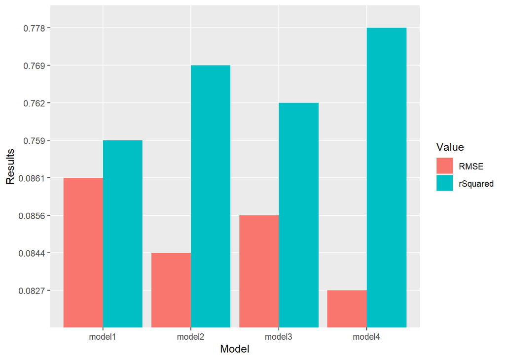

```r
#Create the table
Model <- c("model1", "model1", "model2", "model2", "model3", "model3", "model4", "model4")
Value <- c("rSquared", "RMSE", "rSquared", "RMSE", "rSquared", "RMSE", "rSquared", "RMSE")
Results <- c("0.759", "0.0861", "0.769", "0.0844", "0.762", "0.0856", "0.778", "0.0827")
results_df <- data.frame(Model, Value, Results)
#create the visual
ggplot(results_df, aes(x = Model, y = Results, fill =Value ))+
geom_bar(stat = "identity", position = "dodge")
```

**Create a Q-Q plot by plotting the distribution difference between the predictions generated by your best model and the true values on the test dataset.**

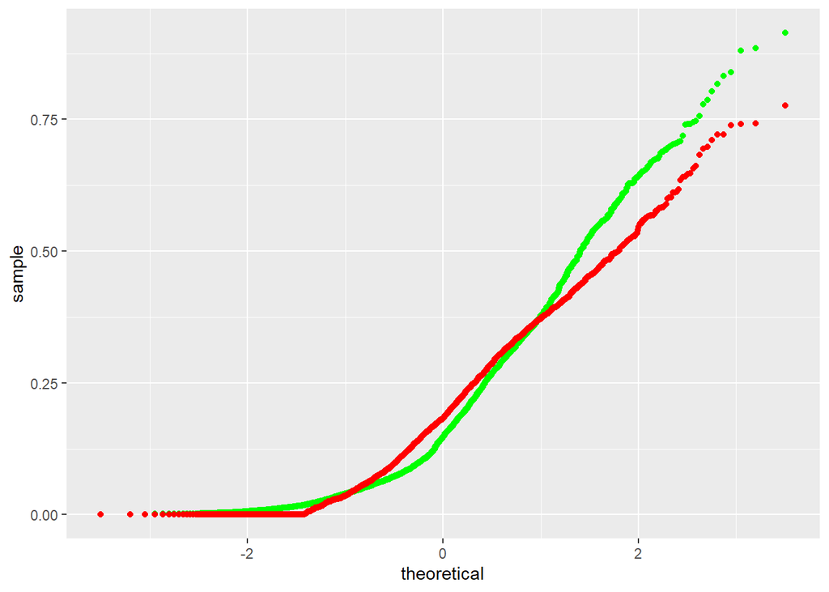

### Predict Forecast Bike Usage

```r
#Filter by Seoul
seoul_forecast <- forecast_data %>%
  filter(CITY_NAME == "Seoul")
colnames(seoul_forecast)
```

```
##  [1] "MAIN"                         "DESCRIPTION"
##  [3] "VISIBILITY"                   "PROBABILITY_OF_PRECIPITATION"
##  [5] "DATE"                         "HOUR_INTERVAL"
##  [7] "TEMPERATURE"                  "FEELS_LIKE"
##  [9] "TEMP_MIN"                     "TEMP_MAX"
## [11] "PRESSURE"                     "LIST.MAIN.SEA_LEVEL"
## [13] "GRND_LEVEL"                   "HUMIDITY"
## [15] "TEMP_KF"                      "CLOUDS_ALL"
## [17] "WIND_SPEED"                   "WIND_DEG"
## [19] "WIND_GUST"                    "SYS_POD"
## [21] "RAIN_OVER_3H"                 "CITY_NAME"
## [23] "CITY_COORD_LAT"               "CITY_COORD_LON"
## [25] "CITY_COUNTRY"                 "CITY_POPULATION"
## [27] "CITY_TIMEZONE"
```

```r
unique(seoul_forecast$HOUR_INTERVAL)
```

```
## [1] "09:00:00" "12:00:00" "15:00:00" "18:00:00" "21:00:00" "00:00:00" "03:00:00"
## [8] "06:00:00"
```

```r
unique(seoul_forecast$DATE)
```

```
## [1] "02/11/2024" "03/11/2024" "04/11/2024" "05/11/2024" "06/11/2024"
## [6] "07/11/2024"
```

```r
seoul_forecast <- seoul_forecast %>%
  select(-MAIN, -DESCRIPTION, -PROBABILITY_OF_PRECIPITATION, -DATE, -FEELS_LIKE, -TEMP_MIN, -TEMP_MAX, -PRESSURE, -LIST.MAIN.SEA_LEVEL, -GRND_LEVEL, -TEMP_KF, -CLOUDS_ALL, -WIND_DEG, -WIND_GUST, -SYS_POD, -CITY_NAME,-CITY_COORD_LAT,-CITY_COORD_LON, -CITY_COUNTRY,-CITY_POPULATION, -CITY_TIMEZONE) %>%
  rename(RAINFALL = RAIN_OVER_3H)
summary(seoul_forecast)
```

```
##    VISIBILITY    HOUR_INTERVAL       TEMPERATURE        HUMIDITY
##  Min.   :10000   Length:40          Min.   : 4.530   Min.   :15.00
##  1st Qu.:10000   Class :character   1st Qu.: 8.643   1st Qu.:29.00
##  Median :10000   Mode  :character   Median :10.675   Median :38.00
##  Mean   :10000                      Mean   :12.323   Mean   :42.23
##  3rd Qu.:10000                      3rd Qu.:16.852   3rd Qu.:53.25
##  Max.   :10000                      Max.   :21.760   Max.   :83.00
##    WIND_SPEED       RAINFALL
##  Min.   :0.490   Min.   :0.000
##  1st Qu.:1.802   1st Qu.:0.000
##  Median :3.290   Median :0.000
##  Mean   :3.412   Mean   :0.048
##  3rd Qu.:5.075   3rd Qu.:0.000
##  Max.   :6.780   Max.   :1.320
```

Now I’ll create the solar radiation column and put in the avg from the SQL search based on the HOUR_INTERVAL column that I created, this one I have more control over and is abit more important when it comes to the data, as visualised time of data really impacts amount of solar radiation.

```r
avg_solar <- function(hour_interval){
  case_when(
    hour_interval %in% c("00:00:00") ~0,
    hour_interval %in% c("03:00:00") ~0,
    hour_interval %in% c("06:00:00") ~0.09,
    hour_interval %in% c("09:00:00") ~1.2,
    hour_interval %in% c("12:00:00") ~1.82,
    hour_interval %in% c("15:00:00") ~1.01,
    hour_interval %in% c("18:00:00") ~0.06,
    hour_interval %in% c("21:00:00") ~0,
    TRUE ~ NA_real_
  )
}
seoul_forecast <- seoul_forecast %>%
  mutate(SOLAR_RADIATION = avg_solar(HOUR_INTERVAL))
unique(seoul_forecast$SOLAR_RADIATION)
```

```
## [1] 1.20 1.82 1.01 0.06 0.00 0.09
```

```r
seoul_forecast <- seoul_forecast %>%
  mutate(DEW_POINT_TEMPERATURE = 0.571,
         SNOWFALL = 0, Autumn = 1, Summer = 0, Spring = 0,
         Winter = 0, VISIBILITY = VISIBILITY / 10000,
         `No Holiday` = 1, Holiday = 0, RAINFALL = 0.0363,
         HOUR_INTERVAL = substr(HOUR_INTERVAL,1, 5))
summary(seoul_forecast)
```

```
##    VISIBILITY HOUR_INTERVAL       TEMPERATURE        HUMIDITY
##  Min.   :1    Length:40          Min.   : 4.530   Min.   :15.00
##  1st Qu.:1    Class :character   1st Qu.: 8.643   1st Qu.:29.00
##  Median :1    Mode  :character   Median :10.675   Median :38.00
##  Mean   :1                       Mean   :12.323   Mean   :42.23
##  3rd Qu.:1                       3rd Qu.:16.852   3rd Qu.:53.25
##  Max.   :1                       Max.   :21.760   Max.   :83.00
##    WIND_SPEED       RAINFALL      SOLAR_RADIATION  DEW_POINT_TEMPERATURE
##  Min.   :0.490   Min.   :0.0363   Min.   :0.0000   Min.   :0.571
##  1st Qu.:1.802   1st Qu.:0.0363   1st Qu.:0.0000   1st Qu.:0.571
##  Median :3.290   Median :0.0363   Median :0.0750   Median :0.571
##  Mean   :3.412   Mean   :0.0363   Mean   :0.5225   Mean   :0.571
##  3rd Qu.:5.075   3rd Qu.:0.0363   3rd Qu.:1.0575   3rd Qu.:0.571
##  Max.   :6.780   Max.   :0.0363   Max.   :1.8200   Max.   :0.571
##     SNOWFALL     Autumn      Summer      Spring      Winter    No Holiday
##  Min.   :0   Min.   :1   Min.   :0   Min.   :0   Min.   :0   Min.   :1
##  1st Qu.:0   1st Qu.:1   1st Qu.:0   1st Qu.:0   1st Qu.:0   1st Qu.:1
##  Median :0   Median :1   Median :0   Median :0   Median :0   Median :1
##  Mean   :0   Mean   :1   Mean   :0   Mean   :0   Mean   :0   Mean   :1
##  3rd Qu.:0   3rd Qu.:1   3rd Qu.:0   3rd Qu.:0   3rd Qu.:0   3rd Qu.:1
##  Max.   :0   Max.   :1   Max.   :0   Max.   :0   Max.   :0   Max.   :1
##     Holiday
##  Min.   :0
##  1st Qu.:0
##  Median :0
##  Mean   :0
##  3rd Qu.:0
##  Max.   :0
```

```r
#Creating a new one-hot coding formula but this time for HOUR_INTERVAL
cols1 <- c("HOUR_INTERVAL")
dummy_time <- function(data, cols1) {
  for (col in cols1) {
    data <- data %>%
      mutate(dummy = 1) %>%
      spread(key = col, value = dummy, fill = 0)
  }
  return(data)
  }
seoul_forecast <- dummy_time(seoul_forecast, cols1)
```

```r
#I'm putting the values from the corresponding hour interval into new columns.
seoul_forecast <- seoul_forecast %>%
  mutate(`01:00` = `00:00`, `02:00` = `00:00`, `04:00` = `03:00`,
         `05:00` = `03:00`,`07:00` = `06:00`, `08:00` = `06:00`,
         `10:00` = `09:00`, `11:00` = `09:00`, `13:00` = `12:00`,
         `14:00` = `12:00`, `16:00` = `15:00`, `17:00` = `15:00`,
         `19:00` = `18:00`,`20:00` = `18:00`,`22:00` = `21:00`,
         `23:00` = `21:00`)
```

```r
#I have the normalise function from before i just needed to make new column search to apply
columns_to_normalise2 <- c(2,3,4,6)
seoul_forecast[columns_to_normalise2] <- lapply(seoul_forecast[columns_to_normalise2], normalise)
```

```r
#Using the prediction formula from the last model I made to apply to the forecast data set
forecast_predictions <-  predict(final_fit4, new_data =seoul_forecast)
forecast_predictions_df <- seoul_forecast %>%
  mutate(RENTED_BIKE_COUNT = ifelse(forecast_predictions$.pred < 0, 0, forecast_predictions$.pred))
summary(forecast_predictions_df$RENTED_BIKE_COUNT)
```

```
##    Min. 1st Qu.  Median    Mean 3rd Qu.    Max.
## 0.00000 0.01029 0.18627 0.26970 0.41391 0.92155
```

```r
seoul_normalised_counts <- seoul_normalise %>%
  filter(Autumn == 1) %>%
  select(RENTED_BIKE_COUNT)
  summary(seoul_normalised_counts)
```

```
##  RENTED_BIKE_COUNT
##  Min.   :0.0000
##  1st Qu.:0.1215
##  Median :0.2393
##  Mean   :0.2589
##  3rd Qu.:0.3566
##  Max.   :0.9274
```

## **Project Close-Out Summary**

**Instructor Credits**  
I would like to express my gratitude to the instructors from the two IBM courses that incorporated the skills learnt in this analysis:  
**Rav Ahuja**  
**Saishruthi Swaminathan**  
**Sandip Saha Joy**  
**Steve Ryan**  
**Yan Luo**  
**Kevin McFaul**  
**Yiwen Li**  
**Gabriela de Queiroz**  
**Jeff Grossman**  
**Tiffany Zhu**  
**Dr. Pooja**  
**Murtaza Haider**  
**Ramesh Sannareddy**  
Artist: Malte Marten was in constant rotation throughout this project  
Til next time, DONT PANIC!